# Phase_1+2

### **Reddit Engagement Analysis: Prediction and Pattern Discovery**

#### *Phase 1 & Phase 2*

#### **Submitted By:**

**Affan Thameem**  
Student ID: 40282375  
Section: COMP 333 - GJ-X

**Mohammad Salah Sartawi**  
Student ID: 40246396  
Section: COMP 333 - GJ-X

**Chimdindu Okelekwe**  
Student ID: 40153875  
Section: COMP 333 - GI-X

#### **Course Information**

**Course:** COMP 333  
**Instructor:** Alexis Danilo Yáñez Inostroza  
**Due Date:** April 5, 2026

- Phase 1 — Data Acquisition & Baseline
- 1. Prerequisites
  - 1.1 Import All Packages
  - 1.2 Data Retrieval
  - 1.3 Select Dataset
- 2. Wrangling & Cleaning
  - 2.1 Initial Audit (Missing, Duplicates, Outliers)
  - 2.2 Reproducible Cleaning Pipeline (RQ1 & RQ2)
  - 2.3 quantDDA() and vizDDA()
- 3. Exploratory Data Analysis (EDA)
  - 3.1 Purpose
  - 3.2 Summary Statistics
  - 3.3 Target Variable Distribution
  - 3.4 Univariate Analysis
  - 3.5 Bivariate Analysis
  - 3.6 Correlation Analysis
  - 3.7 Data Quality Confirmation
  - 3.8 Summary of Insights
- 4. Baseline Model
  - 4.1 Feature Engineering for Modeling
  - 4.2 Train / Validation / Test Split
  - 4.3 Model Training — Logistic Regression
  - 4.4 Evaluation
  - 4.5 Performance Discussion
- 5. Report
- Phase 2 — Advanced Modeling
- 6. Advanced Supervised Learning (RQ1)
  - 6.1 Shared Utilities
  - 6.2 Model 1 — Random Forest
  - 6.3 Model 2 — XGBoost
  - 6.4 Systematic Model Comparison
  - 6.5 Best Model Justification
  - 6.6 Feature Importance — Random Forest & XGBoost
- 7. Feature Engineering
  - 7.1 Objective
  - 7.2 Design Strategy
  - 7.3 Feature Selection Plan
  - 7.4 Feature Engineering
  - 7.5 Feature Selection
- 8. Unsupervised Learning
  - 8.1 Objective
  - 8.2 Why PCA + Clustering is Appropriate Here
- 9. Phase 2 Model Comparison — Before vs. After Feature Engineering
  - 9.1 Discussion — Feature Engineering Impact
- 10. Interpretation
  - 10.1 Permutation Importance
  - 10.2 Partial Dependence Plots
  - 10.3 Insights & Research Questions
- 11. Report

### Phase 1 — Data Acquisition & Baseline

**Due:** Tuesday, March 3rd, 2026

#### Division of Labour

| Section | Contributor |
| --- | --- |
| Data Retrieval | Affan Thameem |
| Wrangling/Cleaning | Affan Thameem |
| EDA | Chimdindu Okelekwe |
| Baseline Model | Mohammad Salah |
| Documentation | All |

#### Objective & Research Questions

**RQ1 (Supervised):** Can we predict **high engagement** (score ≥ 80th percentile) from content and structural features?

- **Features:** `title_length`, `has_selftext`, `subreddit`, `content_type`, `hour_of_day`, `day_of_week`, `is_weekend`, `domain`

**RQ2 (Unsupervised):** Can we discover natural clusters of Reddit submissions based on engagement patterns, subreddit, and content structure **without using the score label**?

- **Features:** `title_length`, `has_selftext`, `subreddit`, `content_type`, `hour_of_day`, `day_of_week`, `is_weekend`, `domain`

### 1. Prerequisites

#### 1.1 Import all packages

```python
# Standard library
import io
import json
import os
import random
import re
import warnings
import zipfile

# Data & computation
import pandas as pd
import numpy as np

# Visualization
import matplotlib.pyplot as plt
import seaborn as sns

# Third-party utilities
import gdown
import zstandard as zstd
from tqdm import tqdm

# XGBoost
import xgboost as xgb

# scikit-learn: model selection & preprocessing
from sklearn.base import clone
from sklearn.model_selection import (
    train_test_split, RandomizedSearchCV, StratifiedKFold,
)
from sklearn.preprocessing import StandardScaler

# scikit-learn: models
from sklearn.linear_model import LogisticRegression
from sklearn.ensemble import RandomForestClassifier

# scikit-learn: feature selection
from sklearn.feature_selection import SelectKBest, mutual_info_classif, RFECV

# scikit-learn: metrics
from sklearn.metrics import (
    accuracy_score, precision_score, recall_score,
    f1_score, roc_auc_score,
    confusion_matrix, ConfusionMatrixDisplay,
    roc_curve, precision_recall_curve, average_precision_score,
    silhouette_score, davies_bouldin_score, calinski_harabasz_score,
)

# scikit-learn: dimensionality reduction & clustering
from sklearn.decomposition import PCA, TruncatedSVD
from sklearn.cluster import MiniBatchKMeans

# scikit-learn: model inspection
from sklearn.inspection import permutation_importance, PartialDependenceDisplay

# Global settings
pd.set_option('display.float_format', '{:.2f}'.format)
warnings.filterwarnings("ignore")
```

#### 1.2 Data Retrieval (Document Sources; Programmatic Retrieval; Challenges; Raw Storage)

#### **Document sources**

- **Primary source:** Reddit submissions (January 2026) obtained from [Academic Torrents](https://academictorrents.com/details/8412b89151101d88c915334c45d9c223169a1a60) (Pushshift/Reddit data dump).
- **Access method:** BitTorrent client (e.g., [Transmission](https://transmissionbt.com/)) to download the compressed `RS_2026-01.zst` file (~19.6 GB).

#### **Programmatic retrieval**

- We use **file-based streaming extraction** (no API or SQL queries).
- The Python `zstandard` library decompresses the `.zst` archive and streams the data line-by-line.
- Each line represents one Reddit submission in JSON format.
- During streaming:
  - JSON lines are parsed using json.loads().
  - NSFW posts (over_18 = True) are excluded.
  - Only a predefined subset of relevant fields is retained.
  - Extraction stops once a ~2 GB subset is written to disk.

This streaming approach assures memory efficiency and avoids loading the full 19.6 GB archive into RAM.

#### **Handling challenges**

- **Rate limits:** Not applicable - data is downloaded via torrent and processed locally.
- **Authentication:** Not required - dataset is publicly available.
- **Data quality:**
  - NSFW content is filtered during extraction.
  - Only fields required for research questions are retained to reduce noise and storage overhead.

#### **Raw data storage**

- Output file: `reddit_subset.jsonl` (~2.15 GB, ~3.85 M posts).
- Format: JSON Lines (one Reddit submission per line).
- The stored dataset does **not** preserve all original 152 fields; instead, it retains only the 9 fields necessary for analysis: `id`, `subreddit`, `created_utc`, `title`, `selftext`, `is_self`, `is_video`, `domain`, `score`

This storage strategy:

- Ensures reproducibility while reducing unnecessary metadata.
- Prevents data leakage by excluding post-engagement fields (e.g., comments, awards).
- Preserves all variables required to derive structural and contextual features for both supervised (RQ1) and unsupervised (RQ2) analyses.
- Maintains a manageable dataset size for local computation while remaining statistically representative.

#### **Random subsetting**

Due to the large size of the full extraction (~2.15 GB), three smaller subsets were created via **uniform random sampling** to support efficient experimentation on lower-resource machines:

| Subset | Sample Ratio | Approx. Size | Approx. Posts |
| --- | --- | --- | --- |
| `reddit_1_5GB.jsonl` | 70 % | 1.50 GB | ~2.69 M |
| `reddit_1GB.jsonl` | 50 % | 1.00 GB | ~1.92 M |
| `reddit_500MB.jsonl` | 25 % | 0.50 GB | ~0.96 M |

Each line in the full file is independently included with probability equal to the sample ratio, preserving the original distribution of subreddits, time periods, and engagement levels without introducing selection bias. All subsets share the same schema and JSON Lines format as the full extraction.

> **Note:** Both the extraction and subsetting cells below are pre-executed and commented out. The pre-built datasets are available for download in **Section 1.3**.

```python
# INPUT_FILE_PATH = "../Dataset/RS_2026-01.zst"
# OUTPUT_FILE_PATH = "reddit_subset.jsonl"
# TARGET_SIZE_BYTES = 2 * 1024**3  # 2GB

# FIELDS_TO_KEEP = [
#     "id",           # Unique post identifier (used for tracking/deduplication, not as a feature)
#     "subreddit",    # Captures community context and engagement norms
#     "created_utc",  # Used to derive time-based features (hour, day, weekend)
#     "title",        # Used to compute title length and optional text features
#     "selftext",     # Used to detect content presence and optional text features
#     "is_self",      # Indicates text post vs link post (post type feature)
#     "is_video",     # Indicates video content (post type feature)
#     "score",        # Used only to create high-engagement label (not as input feature)
#     "domain",       # Identifies external source platform for refining post type
# ]

# bytes_written = 0
# rows_written = 0

# with open(INPUT_FILE_PATH, "rb") as compressed_file:
#     decompressor = zstd.ZstdDecompressor()

#     with decompressor.stream_reader(compressed_file) as decompressed_stream:
#         text_stream = io.TextIOWrapper(decompressed_stream, encoding="utf-8", errors="replace")

#         with open(OUTPUT_FILE_PATH, "w", encoding="utf-8") as output_file:
#             for raw_line in tqdm(text_stream, desc="Extracting submissions"):
#                 submission = json.loads(raw_line)  # Will raise if malformed (handled in Part 2)

#                 # Filter out NSFW content
#                 if submission.get("over_18"):
#                     continue

#                 filtered_submission = {field: submission.get(field) for field in FIELDS_TO_KEEP}

#                 json_line = json.dumps(filtered_submission, ensure_ascii=False) + "\n"
#                 output_file.write(json_line)

#                 bytes_written += len(json_line.encode("utf-8"))
#                 rows_written += 1

#                 if bytes_written >= TARGET_SIZE_BYTES:
#                     break

# print("Done! Extracted ~2GB subset.")
# print(f"Rows written: {rows_written:,}")
# print(f"Total written: {bytes_written / (1024**3):.2f} GB")
```

##### Subset Creation (pre-executed)

The cell below uses uniform random sampling to produce the 1.5 GB, 1 GB, and 500 MB subsets described above.

```python
# def create_random_subsets(input_file, output_file, sample_ratio):
#     """
#     Random sampling for large JSONL files
#     """
#     with open(input_file, "r", encoding="utf-8") as infile, \
#          open(output_file, "w", encoding="utf-8") as outfile:

#         lines_written = 0

#         for line in infile:
#             if random.random() < sample_ratio:
#                 outfile.write(line)
#                 lines_written += 1

#     print(f"Random subset saved: {output_file}")
#     print(f"Lines written: {lines_written:,}")
```

```python
# create_random_subsets(OUTPUT_FILE_PATH, "reddit_500MB.jsonl", 0.25)
# create_random_subsets(OUTPUT_FILE_PATH, "reddit_1GB.jsonl", 0.5)
# create_random_subsets(OUTPUT_FILE_PATH, "reddit_1_5GB.jsonl", 0.7)
```

#### 1.3 Select Dataset

Choose one of the pre-extracted subsets below based on your available memory and desired runtime.

| Dataset | Size | Posts | Link |
| --- | --- | --- | --- |
| Dataset 1 (Full) | 2.15 GB | ~3.85 M | [Download](https://drive.google.com/file/d/1W6mqYfel_PRtVGaikCB-HepsuLJ4buWT/view?usp=sharing) |
| Dataset 2 | 1.50 GB | ~2.69 M | [Download](https://drive.google.com/file/d/1uK1CG1nWNu00fkIQO5zrJbC02sITj7U7/view?usp=sharing) |
| Dataset 3 | 1.00 GB | ~1.92 M | [Download](https://drive.google.com/file/d/19afx8E9rm5nGQ3isregVp6Y_PwGq6tEx/view?usp=sharing) |
| Dataset 4 (Light) | 0.50 GB | ~0.96 M | [Download](https://drive.google.com/file/d/13TXBzK0r22c67FuWl7QQCCdvccXARQ1L/view?usp=sharing) |

> **Recommendation:** Dataset 4 (500MB) is sufficient for development and testing, while Dataset 3 (1.00GB) was be used for final experiments and reporting in Phase 2.

```python
def download_and_prepare_dataset(mode):
    datasets = {
        "full": {
            "name": "2.15GB",
            "file_id": "1W6mqYfel_PRtVGaikCB-HepsuLJ4buWT",
            "filename": "reddit_subset.zip",
            "is_zip": True
        },
        "large": {
            "name": "1.5GB",
            "file_id": "1uK1CG1nWNu00fkIQO5zrJbC02sITj7U7",
            "filename": "reddit_1_5GB.jsonl",
            "is_zip": False
        },
        "medium": {
            "name": "1GB",
            "file_id": "19afx8E9rm5nGQ3isregVp6Y_PwGq6tEx",
            "filename": "reddit_1GB.jsonl",
            "is_zip": False
        },
        "demo": {
            "name": "500MB",
            "file_id": "13TXBzK0r22c67FuWl7QQCCdvccXARQ1L",
            "filename": "reddit_500MB.jsonl",
            "is_zip": False
        }
    }

    if mode not in datasets:
        raise ValueError("Invalid mode")

    dataset = datasets[mode]
    filename = dataset["filename"]

    # 2. Extract if ZIP
    if dataset["is_zip"]:
        extracted_jsonl = None
        if os.path.exists(filename):
            with zipfile.ZipFile(filename, 'r') as zip_ref:
                for file in zip_ref.namelist():
                    if file.endswith(".jsonl") and os.path.exists(file):
                        extracted_jsonl = file
                        break

        if extracted_jsonl:
            print(f" Already extracted. Using: {extracted_jsonl}")
            return extracted_jsonl

        # Download if zip not present
        if not os.path.exists(filename):
            print(f" Downloading {dataset['name']} dataset...")
            url = f"https://drive.google.com/uc?id={dataset['file_id']}"
            gdown.download(url, filename, quiet=False)

        print(" Extracting ZIP...")
        with zipfile.ZipFile(filename, 'r') as zip_ref:
            zip_ref.extractall()
            for file in zip_ref.namelist():
                if file.endswith(".jsonl"):
                    print(f" Using: {file}")
                    return file

    else:
        # For plain .jsonl files, skip download if file already exists
        if os.path.exists(filename):
            print(f" File already exists. Using: {filename}")
            return filename

        print(f" Downloading {dataset['name']} dataset...")
        url = f"https://drive.google.com/uc?id={dataset['file_id']}"
        gdown.download(url, filename, quiet=False)

    print(f" Using: {filename}")
    return filename
```

```python
# mode="full"     2.15GB
# mode="large"    1.5GB
# mode="medium"   1GB
# mode="demo"     500MB

INPUT_FILE = download_and_prepare_dataset("medium")
```

```
 File already exists. Using: reddit_1GB.jsonl
```

## 2. Wrangling & Cleaning

This section performs an **initial audit** (missing values, duplicates, outliers) and applies a **reproducible cleaning pipeline**. We use `quantDDA()` and `vizDDA()` from Lab 2 for quantitative and visual data quality checks.

### 2.1 Initial Audit (Missing, Duplicates, Outliers)

```python
def audit_dataframe(df):
    """Initial audit: missing values, duplicates, basic outlier context."""
    return {
        "shape": df.shape,
        "missing": df.isnull().sum().sort_values(ascending=False),
        "missing_pct": (df.isnull().mean() * 100).round(2).sort_values(ascending=False),
        "duplicate_ids": df["id"].duplicated().sum() if "id" in df.columns else 0,
        "dtypes": df.dtypes
    }

df = pd.read_json(INPUT_FILE, lines=True)
audit = audit_dataframe(df)
print("Shape:", audit["shape"])

print("\n=== COLUMN DTYPES ===")
print(audit["dtypes"])

print("\n=== TOP MISSING VALUES (count) ===")
print(audit["missing"].head(20))

print("\n=== TOP MISSING VALUES (%) ===")
print(audit["missing_pct"].head(20))

print("\n=== DUPLICATES ===")
print("Duplicate IDs:", audit["duplicate_ids"])

# Score distribution checks (target variable source)
print("\n=== SCORE DESCRIBE ===")
print(df["score"].describe())

print("\n=== SCORE QUANTILES ===")
print(df["score"].quantile([0.5, 0.75, 0.8, 0.9, 0.95]))
```

```
Shape: (1926432, 9)

=== COLUMN DTYPES ===
id               str
subreddit        str
created_utc    int64
title            str
selftext         str
is_self         bool
is_video        bool
score          int64
domain           str
dtype: object

=== TOP MISSING VALUES (count) ===
id             0
subreddit      0
created_utc    0
title          0
selftext       0
is_self        0
is_video       0
score          0
domain         0
dtype: int64

=== TOP MISSING VALUES (%) ===
id            0.00
subreddit     0.00
created_utc   0.00
title         0.00
selftext      0.00
is_self       0.00
is_video      0.00
score         0.00
domain        0.00
dtype: float64

=== DUPLICATES ===
Duplicate IDs: 0

=== SCORE DESCRIBE ===
count   1926432.00
mean         52.37
std         641.00
min           0.00
25%           1.00
50%           1.00
75%           9.00
max      169757.00
Name: score, dtype: float64

=== SCORE QUANTILES ===
0.50     1.00
0.75     9.00
0.80    14.00
0.90    54.00
0.95   146.00
Name: score, dtype: float64
```

### 2.2 Reproducible Cleaning Pipeline (RQ1 & RQ2)

For consistency and reproducibility across both research questions, we implemented a preprocessing function, `clean_reddit_data()`, which normalizes the dataset and engineers structural features required for analysis.

The raw dataset contains the following retained fields: `id`, `subreddit`, `created_utc`, `title`, `selftext`, `is_self`, `is_video`, `domain`, and `score`.

From these raw fields, additional columns are created:

- `high_engagement` → binary target variable defined as score ≥ 80th percentile
- `title_length` → character length of the submission title
- `has_selftext` → binary indicator of whether real body content is present
- `content_type` → categorical feature derived from `is_self`, `is_video`, and `domain` (text, video, image, or link)
- `hour_of_day` → UTC hour extracted from `created_utc`
- `day_of_week` → weekday index (0–6)
- `is_weekend` → binary weekend indicator

#### Data Cleaning Decisions

**`content_type` over `post_type`:** An earlier version of this pipeline used a `post_type` feature derived solely from Reddit metadata flags (`is_self`, `is_video`), producing three categories: *self*, *video*, and *link*. However, Reddit metadata was found to be inconsistent with actual post content. For example, posts with `is_self = False` that nevertheless contain substantial body text, or video posts hosted on `v.redd.it` that lack the `is_video` flag. To address this, `content_type` was engineered using a combination of metadata and content-based signals (e.g., presence of real text via `has_selftext`, and domain inspection for `i.redd.it` / `v.redd.it`). This yields four more accurate categories — *text*, *image*, *video*, and *link* — resulting in a more reliable and interpretable representation of post formats.

**Sentinel value handling:** Reddit represents deleted or moderated content with the placeholder strings `[removed]` and `[deleted]`. These are not empty strings and would pass a naive `str.strip() != ""` check, causing them to be falsely counted as real content. The pipeline explicitly detects and excludes these sentinel values when filtering invalid titles and computing `has_selftext`.

**Outlier treatment:** Both `score` and `title_length` contain extreme outliers as identified during DDA. Rather than removing these rows, outliers are capped at the 1st and 99th percentiles. Viral posts (extreme scores) are precisely the signal RQ1 aims to predict — their removal would bias the engagement label and underrepresent the high-engagement class. Capping bounds the influence of extreme values while preserving rank order and retaining all observations.

**Label construction ordering:** The `high_engagement` label is derived from the raw `score` distribution *before* capping is applied. This ensures the 80th-percentile threshold reflects the true engagement distribution and is not influenced by the clipping transformation applied to the feature.

#### Target Definition (RQ1 — Supervised Learning)

Reddit engagement follows a heavily right-skewed distribution. To produce a stable binary classification task, high engagement is defined as submissions with a score at or above the 80th percentile of the raw score distribution. This yields the binary variable `high_engagement`.

#### RQ1 (Supervised Modeling)

The engineered structural features (`title_length`, `has_selftext`, `subreddit`, `content_type`, `hour_of_day`, `day_of_week`, `is_weekend`, and `domain`) are used to predict the binary outcome `high_engagement`.

#### RQ2 (Unsupervised Clustering)

The same structural and contextual features are used for clustering analysis. The engagement variable (`score`) and derived label (`high_engagement`) are excluded from clustering inputs to prevent information leakage and avoid biased evaluation outcomes. After forming clusters without using score, we examine how engagement varies across clusters to understand what each cluster represents.

#### Reproducibility Guarantees

The cleaning pipeline ensures reproducibility by:

- Applying deterministic feature transformations
- Explicitly defining and documenting all derived columns
- Handling Reddit-specific sentinel values (`[removed]`, `[deleted]`) beyond standard null checks
- Capping outliers at the 1st/99th percentile with documented justification
- Constructing the engagement label prior to any outlier transformation
- Removing duplicate submission IDs
- Using identical preprocessing logic for both RQ1 and RQ2

```python
# Constants
REDDIT_SENTINELS = {"removed", "deleted"}
CAP_COLS = {"score", "title_length"}
CAP_JUSTIFICATION = (
    "Outliers capped at 1st/99th pct — viral posts are high-signal for RQ1; "
    "removal would bias the engagement label. Capping preserves rank order."
)

# Helpers
def is_invalid_text(text: str) -> bool:
    """Return True for empty, [removed], or [deleted] Reddit strings."""
    text = str(text).lower().strip()
    text = re.sub(r'[\[\](){}]', '', text)
    text = re.sub(r'\s+', ' ', text).strip()
    return text == "" or any(sentinel in text for sentinel in REDDIT_SENTINELS)


def cap_outliers(series: pd.Series, lower_q: float = 0.01, upper_q: float = 0.99) -> pd.Series:
    """Clip series to [lower_q, upper_q] percentile range."""
    return series.clip(series.quantile(lower_q), series.quantile(upper_q))


# Main pipeline
def clean_reddit_data(raw_path_or_df, engagement_quantile: float = 0.80) -> pd.DataFrame:
    """
    Full cleaning + feature engineering pipeline.

    Steps
    -----
    1. Load & copy
    2. Normalize text fields; remove empty / sentinel titles
    3. `has_selftext` — sentinel-aware (catches [removed] / [deleted])
    4. Target label  (RQ1)
    5. Feature engineering
    6. Outlier capping, score & title_length capped at 1st/99th pct
       Rationale: viral posts are the signal RQ1 predicts; removal would
       bias the engagement label. Capping bounds influence while preserving
       rank order.
    7. Deduplication
    8. Final NaN drop
    """

    # 1. Load
    df = (
        pd.read_json(raw_path_or_df, lines=True)
        if isinstance(raw_path_or_df, str)
        else raw_path_or_df.copy()
    )

    # 2. Normalize & remove bad titles
    df["title"]    = df["title"].fillna("").astype(str).str.strip()
    df["selftext"] = df["selftext"].fillna("").astype(str).str.strip()
    df["domain"]   = df["domain"].fillna("")

    df = df[~df["title"].apply(is_invalid_text)].copy()

    # 3. str.strip() != "" would falsely count "[removed]" / "[deleted]" as real content
    df["has_selftext"] = (~df["selftext"].apply(is_invalid_text)).astype(int)

    # 4. Target label (RQ1), computed BEFORE capping to reflect raw distribution
    threshold = df["score"].quantile(engagement_quantile)
    df["high_engagement"] = (df["score"] >= threshold).astype(int)

    # 5. Feature engineering
    df["title_length"] = df["title"].str.len()

    # First-match-wins: is_video catches the metadata flag, while the
    # v.redd.it check catches Reddit-hosted videos that lack that flag.
    df["content_type"] = np.select(
        [
            df["is_self"].astype(bool),
            df["is_video"].astype(bool),
            df["domain"].str.contains("i.redd.it", na=False),
            df["domain"].str.contains("v.redd.it", na=False),
        ],
        ["text", "video", "image", "video"],
        default="link"
    )

    created_dt = pd.to_datetime(df["created_utc"], unit="s", utc=True, errors="coerce")
    df["hour_of_day"] = created_dt.dt.hour
    df["day_of_week"] = created_dt.dt.dayofweek
    df["is_weekend"]  = (df["day_of_week"] >= 5).astype(int)

    # 6. Outlier capping (score & title_length)
    for col in CAP_COLS:
        before_min, before_max = df[col].min(), df[col].max()
        df[col] = cap_outliers(df[col])
        print(
            f"[clean] '{col}' capped: [{before_min:.1f}, {before_max:.1f}] → "
            f"[{df[col].min():.1f}, {df[col].max():.1f}]  |  {CAP_JUSTIFICATION}"
        )

    # 7. Deduplication
    df = df.drop_duplicates(subset=["id"], keep="first")

    # 8. Drop rows where time features couldn't be parsed
    df = df.dropna(subset=["hour_of_day", "day_of_week"])

    return df


# RQ2 feature view
def get_rq2_features(df_clean: pd.DataFrame) -> pd.DataFrame:
    """Clustering matrix for RQ2 — excludes score and engagement label."""
    rq2_cols = [
        "subreddit", "title_length", "has_selftext",
        "content_type", "hour_of_day", "day_of_week", "is_weekend", "domain"
    ]
    return df_clean[rq2_cols].copy()


# Run
df_clean = clean_reddit_data(INPUT_FILE, engagement_quantile=0.80)
threshold = df_clean["score"].quantile(0.80)

print("\nCleaned shape          :", df_clean.shape)
print("Engagement threshold     :", threshold)
print("Target distribution      :", df_clean["high_engagement"].value_counts(normalize=True).to_dict())
print("Columns                  :", df_clean.columns.tolist())

df_rq2 = get_rq2_features(df_clean)
print("RQ2 feature shape        :", df_rq2.shape)
```

```
[clean] 'title_length' capped: [1.0, 300.0] → [4.0, 203.0]  |  Outliers capped at 1st/99th pct — viral posts are high-signal for RQ1; removal would bias the engagement label. Capping preserves rank order.
[clean] 'score' capped: [0.0, 169757.0] → [0.0, 815.0]  |  Outliers capped at 1st/99th pct — viral posts are high-signal for RQ1; removal would bias the engagement label. Capping preserves rank order.

Cleaned shape          : (1913109, 16)
Engagement threshold     : 14.0
Target distribution      : {0: 0.7937059519347825, 1: 0.2062940480652174}
Columns                  : ['id', 'subreddit', 'created_utc', 'title', 'selftext', 'is_self', 'is_video', 'score', 'domain', 'has_selftext', 'high_engagement', 'title_length', 'content_type', 'hour_of_day', 'day_of_week', 'is_weekend']
RQ2 feature shape        : (1913109, 8)
```

### 2.3 quantDDA() and vizDDA() (from Lab 2)

We use the `quantDDA()` and `vizDDA()` functions from Lab 2 for quantitative and visual data quality checks. `quantDDA` reports missing values, outliers (IQR), skewness, kurtosis; `vizDDA` produces histograms, scatter plots, boxplots, and heatmaps.

```python
def quantDDA(df):
    summary_list = []

    for col in df.columns:
        series = df[col]

        # Basic counts (for all features)
        n_obs     = len(series)
        n_entries = series.count()
        n_unique  = series.nunique(dropna=True)
        n_missing = series.isna().sum()

        # Mode(s): most frequent value(s)
        if n_unique == n_entries:
            modes = "No mode (all values unique)"
        else:
            modes = series.dropna().mode().tolist()

        # Universal statistics
        summary = {
            "Feature":      col,
            "Observations": int(n_obs),
            "Entries":      int(n_entries),
            "Unique":       int(n_unique),
            "Missing":      int(n_missing),
            "Mode(s)":      modes
        }

        # Numeric-only statistics
        if pd.api.types.is_numeric_dtype(series) and not pd.api.types.is_bool_dtype(series) and n_unique > 2:
            clean = series.dropna()

            if len(clean) > 0:

                # Quartiles
                q1 = clean.quantile(0.25)
                q2 = clean.quantile(0.50)
                q3 = clean.quantile(0.75)

                # IQR outlier bounds
                iqr   = q3 - q1
                lower = q1 - 1.5 * iqr
                upper = q3 + 1.5 * iqr

                # Extreme value thresholds (top/bottom 1%)
                lower_ext = clean.quantile(0.01)
                upper_ext = clean.quantile(0.99)

                # Outlier counts
                n_outliers = int(((clean < lower) | (clean > upper)).sum())
                n_extreme  = int(((clean <= lower_ext) | (clean >= upper_ext)).sum())

                # Document outlier decision — capping handled in clean_reddit_data()
                if col in {"score", "title_length"}:
                    outlier_action = (
                        "Capped at 1st/99th pct in cleaning pipeline. Rationale: viral posts "
                        "are high-signal for RQ1; removal would bias the engagement label."
                    )
                elif n_outliers > 0:
                    outlier_action = "Retained — non-target column, no action taken"
                else:
                    outlier_action = "None detected"

                summary.update({
                    "Mean":               clean.mean(),
                    "Standard Deviation": clean.std(),
                    "Minimum":            clean.min(),
                    "Maximum":            clean.max(),
                    "First Quartile":     q1,
                    "Median":             q2,
                    "Third Quartile":     q3,
                    "Skewness":           clean.skew() if len(clean) > 2 else np.nan,
                    "Kurtosis":           clean.kurt() if len(clean) > 3 else np.nan,
                    "Outliers (IQR)":     n_outliers,
                    "Extreme (1%)":       n_extreme,
                    "Outlier Action":     outlier_action
                })

        summary_list.append(summary)

    return pd.DataFrame(summary_list)
```

```python
# Audit RQ1/RQ2 numeric features
quantDDA(df_clean)
```

|  | Feature | Observations | Entries | Unique | Missing | Mode(s) | Mean | Standard Deviation | Minimum | Maximum | First Quartile | Median | Third Quartile | Skewness | Kurtosis | Outliers (IQR) | Extreme (1%) | Outlier Action |
| --- | --- | --- | --- | --- | --- | --- | --- | --- | --- | --- | --- | --- | --- | --- | --- | --- | --- | --- |
| 0 | id | 1913109 | 1913109 | 1913109 | 0 | No mode (all values unique) | NaN | NaN | NaN | NaN | NaN | NaN | NaN | NaN | NaN | NaN | NaN | NaN |
| 1 | subreddit | 1913109 | 1913109 | 142623 | 0 | [chessquiz] | NaN | NaN | NaN | NaN | NaN | NaN | NaN | NaN | NaN | NaN | NaN | NaN |
| 2 | created_utc | 1913109 | 1913109 | 424681 | 0 | [1767384213] | 1767449709.48 | 124559.82 | 1767225600.00 | 1767658318.00 | 1767344713.00 | 1767453730.00 | 1767557468.00 | -0.03 | -1.19 | 0.00 | 38270.00 | None detected |
| 3 | title | 1913109 | 1913109 | 1612217 | 0 | [Find the best position in 2 moves] | NaN | NaN | NaN | NaN | NaN | NaN | NaN | NaN | NaN | NaN | NaN | NaN |
| 4 | selftext | 1913109 | 1913109 | 1032786 | 0 | [] | NaN | NaN | NaN | NaN | NaN | NaN | NaN | NaN | NaN | NaN | NaN | NaN |
| 5 | is_self | 1913109 | 1913109 | 2 | 0 | [False] | NaN | NaN | NaN | NaN | NaN | NaN | NaN | NaN | NaN | NaN | NaN | NaN |
| 6 | is_video | 1913109 | 1913109 | 2 | 0 | [False] | NaN | NaN | NaN | NaN | NaN | NaN | NaN | NaN | NaN | NaN | NaN | NaN |
| 7 | score | 1913109 | 1913109 | 816 | 0 | [1] | 30.50 | 108.04 | 0.00 | 815.00 | 1.00 | 1.00 | 9.00 | 5.61 | 33.95 | 317983.00 | 213343.00 | Capped at 1st/99th pct in cleaning pipeline. R... |
| 8 | domain | 1913109 | 1913109 | 119666 | 0 | [i.redd.it] | NaN | NaN | NaN | NaN | NaN | NaN | NaN | NaN | NaN | NaN | NaN | NaN |
| 9 | has_selftext | 1913109 | 1913109 | 2 | 0 | [1] | NaN | NaN | NaN | NaN | NaN | NaN | NaN | NaN | NaN | NaN | NaN | NaN |
| 10 | high_engagement | 1913109 | 1913109 | 2 | 0 | [0] | NaN | NaN | NaN | NaN | NaN | NaN | NaN | NaN | NaN | NaN | NaN | NaN |
| 11 | title_length | 1913109 | 1913109 | 200 | 0 | [33] | 46.03 | 34.72 | 4.00 | 203.00 | 23.00 | 37.00 | 60.00 | 1.91 | 4.92 | 85979.00 | 47766.00 | Capped at 1st/99th pct in cleaning pipeline. R... |
| 12 | content_type | 1913109 | 1913109 | 4 | 0 | [text] | NaN | NaN | NaN | NaN | NaN | NaN | NaN | NaN | NaN | NaN | NaN | NaN |
| 13 | hour_of_day | 1913109 | 1913109 | 24 | 0 | [18] | 12.43 | 7.09 | 0.00 | 23.00 | 6.00 | 14.00 | 18.00 | -0.26 | -1.21 | 0.00 | 173932.00 | None detected |
| 14 | day_of_week | 1913109 | 1913109 | 6 | 0 | [0] | 3.56 | 2.10 | 0.00 | 6.00 | 3.00 | 4.00 | 5.00 | -0.67 | -0.82 | 0.00 | 785922.00 | None detected |
| 15 | is_weekend | 1913109 | 1913109 | 2 | 0 | [0] | NaN | NaN | NaN | NaN | NaN | NaN | NaN | NaN | NaN | NaN | NaN | NaN |

```python
def vizDDA(name, df):
    print(f"\n{'=' * 80}\n{name}\n{'=' * 80}")

    df_plot = df.copy()

    max_unique = 10  # Set to 500 to see all columns. Set to 10 for visual purposes (only low-cardinality categorical). Adjust as needed.

    def safe_nunique(s):
        try:
            return s.nunique(dropna=True)
        except (TypeError, ValueError):
            return float('inf')  # Skip columns with unhashable types

    keep_cols = [
        col for col in df_plot.columns
        if pd.api.types.is_numeric_dtype(df_plot[col]) or safe_nunique(df_plot[col]) <= max_unique
    ]  # Keep numeric always + only low-cardinality categorical

    df_plot = df_plot[keep_cols]  # Filter df for readable plotting

    cols = df_plot.columns.tolist()  # Column names used in grid
    n = len(cols)  # Grid size (n x n)

    numeric_cols = df_plot.select_dtypes(include=[np.number]).columns.tolist()  # Numeric columns
    categorical_cols = [c for c in cols if c not in numeric_cols]  # Categorical columns (low-cardinality)

    print("Columns used in grid:", cols)

    fig, axes = plt.subplots(n, n, figsize=(4 * n, 4 * n))  # Create plot grid
    if n == 1:
        axes = np.array([[axes]])

    # Loop through grid
    for i in range(n):
        for j in range(n):
            ax = axes[i, j]  # Current subplot
            row_var = cols[i]  # Y variable
            col_var = cols[j]  # X variable

            # Matrix headers
            if i == 0:
                ax.set_title(col_var)  # Column headers
            if j == 0:
                ax.set_ylabel(row_var)  # Row headers
            else:
                ax.set_ylabel("")  # Reduce clutter

            if i != n - 1:
                ax.set_xlabel("")  # Hide x-label except bottom row

            # Diagonal: Univariate
            if i == j:
                if row_var in numeric_cols:
                    df_plot[row_var].dropna().hist(ax=ax, bins=30, edgecolor="black")
                    cell_label = f"{row_var} (hist)"  # Cell meaning
                else:
                    df_plot[row_var].value_counts().plot(kind="bar", ax=ax)
                    ax.tick_params(axis="x", rotation=45)
                    cell_label = f"{row_var} (bar)"  # Cell meaning

            # Off-diagonal: Bivariate
            else:
                # Numeric vs Numeric -> Scatter
                if row_var in numeric_cols and col_var in numeric_cols:
                    ax.scatter(df_plot[col_var], df_plot[row_var], alpha=0.5, s=15)
                    cell_label = f"{row_var} vs {col_var} (scatter)"  # Cell meaning

                # Numeric vs Categorical -> Boxplot
                elif row_var in numeric_cols and col_var in categorical_cols:
                    sns.boxplot(x=df_plot[col_var], y=df_plot[row_var], ax=ax)
                    ax.tick_params(axis="x", rotation=45)
                    cell_label = f"{row_var} by {col_var} (box)"  # Cell meaning

                # Categorical vs Numeric -> Boxplot (variables flipped)
                elif row_var in categorical_cols and col_var in numeric_cols:
                    sns.boxplot(x=df_plot[row_var], y=df_plot[col_var], ax=ax)
                    ax.tick_params(axis="x", rotation=45)
                    cell_label = f"{col_var} by {row_var} (box)"  # Cell meaning

                # Categorical vs Categorical -> Heatmap
                else:
                    ct = pd.crosstab(df_plot[row_var], df_plot[col_var])
                    sns.heatmap(
                        ct,
                        annot=True,
                        fmt="d",
                        cbar=False,
                        ax=ax,
                        annot_kws={"color": "white"}  # Heatmap numbers in white
                    )
                    ax.tick_params(axis="x", rotation=45)
                    cell_label = f"{row_var} x {col_var} (count)"  # Cell meaning

            # Labeling
            ax.text(
                0.02, 0.95, cell_label,  # Position inside axes (top-left)
                transform=ax.transAxes,
                fontsize=9,
                va="top",
                ha="left",
                bbox=dict(facecolor="white", alpha=0.7, edgecolor="none") # styling
            )

    plt.tight_layout()
    plt.show()

    # Missing values heatmap
    plt.figure(figsize=(10, 6))
    sns.heatmap(df_plot.isna(), cbar=False)
    plt.title("Missing Values Heatmap")
    plt.xlabel("Columns")
    plt.ylabel("Rows")
    plt.tight_layout()
    plt.show()
```

```
================================================================================
DDA Visual Diagnostics (key features)
================================================================================
Columns used in grid: ['score', 'high_engagement', 'title_length', 'has_selftext', 'hour_of_day', 'day_of_week', 'is_weekend', 'content_type']
```

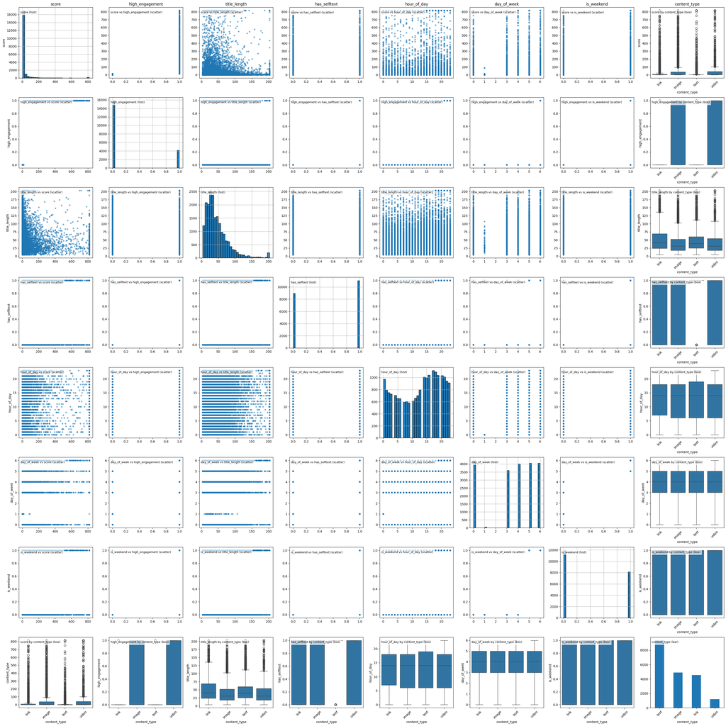

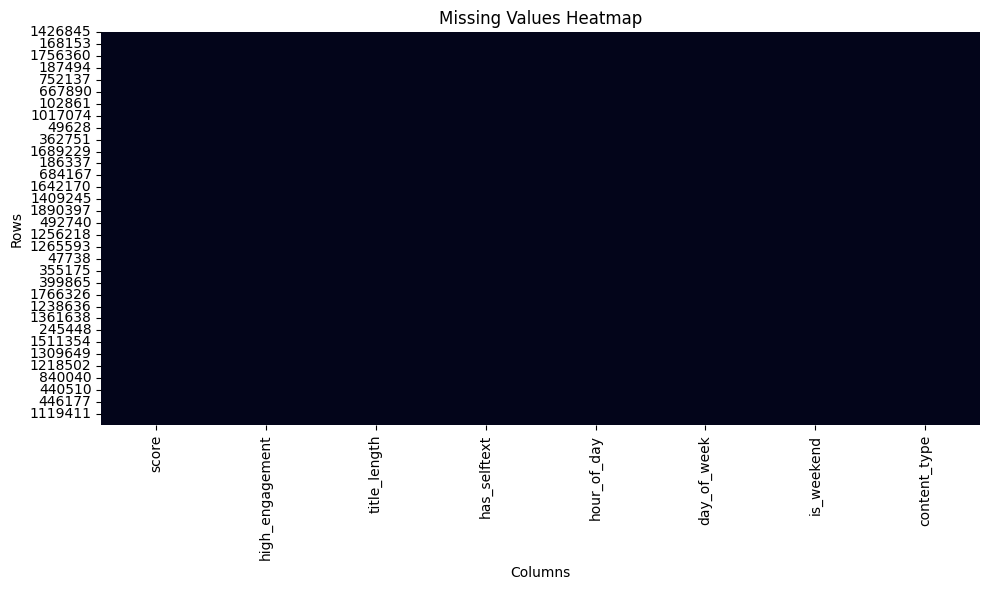

```python
# Viz subset: RQ1/RQ2
cols_for_viz = [
    "score", "high_engagement",
    "title_length", "has_selftext",
    "hour_of_day", "day_of_week", "is_weekend",
    "content_type"
]
vizDDA("DDA Visual Diagnostics (key features)", df_clean[cols_for_viz].sample(20000, random_state=42))
```

## 3. Exploratory Data Analysis (EDA)

### 3.1 Purpose

After completing data retrieval and cleaning, we now explore the dataset to better understand its structure before implementing any predictive models.

The objectives of this EDA are to:

- Examine the statistical properties of the engineered features
- Analyze how structural attributes relate to engagement
- Assess the balance of the target variable
- Identify patterns that may support both supervised and unsupervised learning

All variables analyzed in this section were generated in `clean_reddit_data()` and are aligned with the research questions defined earlier.

### 3.2 Summary Statistics

Using `quantDDA()`, we computed descriptive statistics for the main modeling variables:

- `score`
- `high_engagement`
- `title_length`
- `has_selftext`
- `hour_of_day`
- `day_of_week`

### Score Distribution (Context)

From the audit results:

The distribution of scores is extremely right-skewed. Most posts receive minimal engagement, while a small number receive very high scores. This heavy-tailed behavior is typical of online content platforms and supports the decision to define high engagement using a percentile-based threshold rather than a fixed value.

### 3.3 Target Variable Distribution

The binary target `high_engagement` labels posts above the 80th percentile as 1.

As expected:

- Approximately 20% of posts are labeled high engagement
- Approximately 80% are labeled low engagement

This introduces moderate class imbalance. While not extreme, it suggests that evaluation metrics such as precision, recall, and F1-score will be more informative than accuracy alone in Phase 2.

### 3.4 Univariate Analysis

We use `vizDDA()` to examine the distribution of individual features.

### Title Length

Title length exhibits noticeable variability, with a right-skewed distribution. Most titles are relatively short, but there is a long tail of longer titles.

This variability indicates that title length meaningfully differentiates posts and may capture differences in content detail or intent.

### Has Selftext

`has_selftext` is a binary indicator of whether a post includes body text.

This variable separates link-style posts from discussion-style posts. Since format influences how users interact with content, this structural distinction may play an important role in predicting engagement.

### Post Type

Differences in engagement patterns across formats suggest that user behavior may vary depending on whether a post invites discussion or redirects users to external content.

### Hour of Day

Posting activity is not uniformly distributed across all hours. Some hours show significantly higher activity levels.

This suggests that user engagement on Reddit follows daily behavioral cycles. Time-of-day may therefore contribute predictive value.

### 3.5 Bivariate Analysis

We now examine how structural features relate to engagement.

### Title Length vs High Engagement

This suggests that title length alone is not a strong discriminator, but may contribute predictive signal when combined with other features.

### Has Selftext vs Engagement

Engagement rates differ between posts with and without selftext. Posts containing selftext appear to follow different engagement patterns than link-only posts.

This supports the hypothesis that content format influences user interaction.

### Post Type vs Engagement

Differences between self and link posts are also reflected in engagement distributions. This reinforces the importance of structural features in modeling engagement.

### Subreddit vs Engagement

This suggests that subreddit context captures community-level effects such as audience size, norms, and activity levels. Subreddit is therefore likely to be one of the strongest predictors for RQ1 and a key variable in clustering for RQ2.

### 3.6 Correlation Analysis

- `score`
- `title_length`
- `hour_of_day`
- `day_of_week`

This indicates:

- Low multicollinearity among predictors
- Each feature contributes relatively independent information
- Engagement behavior is unlikely to be explained by simple linear relationships alone

This supports the use of classification models that can capture nonlinear interactions in Phase 2.

### 3.7 Data Quality Confirmation

The missing values heatmap generated by `vizDDA()` shows no missing values in the selected modeling variables.

This confirms that the cleaning pipeline successfully handled missing data and that no additional preprocessing is required before baseline modeling.

### 3.8 Summary of Insights

From this exploratory analysis:

1. Engagement is intentionally imbalanced (~20% high engagement).
2. Score distribution is highly skewed, validating percentile-based thresholding.
3. Structural features (title length, selftext presence, post type) show meaningful variability.
4. Temporal features capture daily behavioral patterns.
5. Subreddit appears to strongly influence engagement.
6. Numeric predictors exhibit low correlation, reducing concerns about redundancy.

Overall, the dataset demonstrates sufficient structure and variability to support both:

- Binary classification (RQ1)
- Clustering based on structural attributes (RQ2)

This EDA provides a clear foundation for implementing and evaluating the baseline model in the next section.

## 4. Baseline Model

We address **RQ1 (Supervised):** predicting `high_engagement` (binary: score ≥ 80th percentile) from content and structural features.

**Target:** `high_engagement` (1 = score ≥ 80th percentile, 0 = otherwise) — approximately **20.5% positive class**.

**Model choice:** Logistic Regression.  
As a baseline it is interpretable via coefficients, fast to train on large data, and well-suited to binary classification. We use `class_weight='balanced'` to account for the ~4:1 class imbalance.

### 4.1 Feature Engineering for Modeling

The full RQ1 feature set (defined in Section 1) is:

| Feature | Type | Encoding |
| --- | --- | --- |
| `title_length` | Numeric | StandardScaler |
| `has_selftext` | Binary numeric | As-is |
| `hour_of_day` | Numeric | StandardScaler |
| `day_of_week` | Numeric | StandardScaler |
| `is_weekend` | Binary numeric | As-is |
| `content_type` | Categorical (4 levels) | One-hot (drop first) |
| `subreddit` | High-cardinality categorical | Top-50 + "Other" → One-hot |
| `domain` | High-cardinality categorical | Top-50 + "Other" → One-hot |

### 4.2 Train / Validation / Test Split

We use a **70 / 15 / 15** split, stratified on the target to preserve the class ratio across all three sets.

```python
# ── 1. Build full feature matrix ─────────────────────────────────────────────

TOP_N = 50  # Number of top levels to keep for high-cardinality features

NUMERIC_FEATURES   = ["title_length", "has_selftext", "hour_of_day", "day_of_week", "is_weekend"]
CATEGORICAL_LOW    = ["content_type"]                   # 3 levels — encode directly
CATEGORICAL_HIGH   = ["subreddit", "domain"]         # 195k / 183k levels — cap at top-50

TARGET = "high_engagement"

df_bl = df_clean[NUMERIC_FEATURES + CATEGORICAL_LOW + CATEGORICAL_HIGH + [TARGET]].copy()

# Cap high-cardinality columns at top-N, rest → "Other"
for col in CATEGORICAL_HIGH:
    top_vals = df_bl[col].value_counts().nlargest(TOP_N).index
    df_bl[col] = df_bl[col].where(df_bl[col].isin(top_vals), other="Other")

# One-hot encode all categorical features (drop first to avoid dummy trap)
df_bl = pd.get_dummies(df_bl, columns=CATEGORICAL_LOW + CATEGORICAL_HIGH, drop_first=True)

X = df_bl.drop(columns=[TARGET])
y = df_bl[TARGET]

print(f"Feature matrix shape : {X.shape}")
print(f"Target distribution  : {y.value_counts(normalize=True).round(4).to_dict()}")

# ── 2. 70 / 15 / 15 stratified split ─────────────────────────────────────────
X_train, X_temp, y_train, y_temp = train_test_split(
    X, y, test_size=0.30, random_state=42, stratify=y
)
X_val, X_test, y_val, y_test = train_test_split(
    X_temp, y_temp, test_size=0.50, random_state=42, stratify=y_temp
)

print(f"\nTrain : {len(X_train):>9,}  ({len(X_train)/len(X)*100:.1f}%)")
print(f"Val   : {len(X_val):>9,}  ({len(X_val)/len(X)*100:.1f}%)")
print(f"Test  : {len(X_test):>9,}  ({len(X_test)/len(X)*100:.1f}%)")
```

```
Feature matrix shape : (1913109, 108)
Target distribution  : {0: 0.7937, 1: 0.2063}

Train : 1,339,176  (70.0%)
Val   :   286,966  (15.0%)
Test  :   286,967  (15.0%)
```

### 4.3 Model Training — Logistic Regression

We fit a **Logistic Regression** with `class_weight='balanced'` so the optimizer up-weights the minority class (high-engagement posts) during training, preventing the model from trivially predicting 0 for every row.

Numeric features are standardized with `StandardScaler` (fit on train only, then applied to val/test to prevent data leakage).

```python
# ── Scale numeric features (fit on train only) ───────────────────────────────
scaler = StandardScaler()
X_train_sc = scaler.fit_transform(X_train)
X_val_sc   = scaler.transform(X_val)
X_test_sc  = scaler.transform(X_test)

# ── Fit logistic regression ───────────────────────────────────────────────────
lr = LogisticRegression(
    max_iter=1000,
    random_state=42,
    class_weight="balanced",
    solver="saga",   # saga supports n_jobs and scales well to large datasets
    n_jobs=-1
)
lr.fit(X_train_sc, y_train)
print("Logistic Regression trained successfully.")

# ── Top 15 most influential coefficients ─────────────────────────────────────
coef_df = (
    pd.DataFrame({"Feature": X.columns, "Coefficient": lr.coef_[0]})
    .reindex(pd.Series(lr.coef_[0]).abs().sort_values(ascending=False).index)
    .head(15)
    .reset_index(drop=True)
)
print("\nTop 15 features by absolute coefficient magnitude:")
print(coef_df.to_string(index=False))
```

```
Logistic Regression trained successfully.

Top 15 features by absolute coefficient magnitude:
                         Feature  Coefficient
                    domain_Other         1.43
                domain_i.redd.it         1.36
               domain_reddit.com         1.22
               content_type_text        -0.87
        subreddit_PokemonGoRaids        -0.64
                domain_v.redd.it         0.63
         subreddit_AutoNewspaper        -0.49
  subreddit_automationContentCom        -0.45
               content_type_link        -0.39
    subreddit_SwordAndSupperGame        -0.38
subreddit_u_playwright_non_admin        -0.36
           domain_self.AskReddit         0.35
  domain_self.SwordAndSupperGame         0.33
            subreddit_BotBouncer        -0.31
                    has_selftext         0.25
```

### 4.4 Evaluation

We evaluate on all three splits using five metrics:

| Metric | Why it matters here |
| --- | --- |
| **Accuracy** | Overall correctness |
| **Precision** | Of predicted high-engagement posts, how many actually are? |
| **Recall** | Of all true high-engagement posts, how many did we catch? |
| **F1-score** | Harmonic mean of Precision and Recall — balances both |
| **ROC-AUC** | Threshold-independent discriminative power; primary metric given class imbalance |

Precision, Recall, and F1 are reported for the **positive (high-engagement) class** since that is the class of interest.

```python
# ── Helper: compute all metrics for one split ────────────────────────────────
def evaluate_split(name, X_sc, y_true):
    y_pred  = lr.predict(X_sc)
    y_proba = lr.predict_proba(X_sc)[:, 1]
    return {
        "Split"    : name,
        "Accuracy" : round(accuracy_score(y_true, y_pred),                       4),
        "Precision": round(precision_score(y_true, y_pred, zero_division=0),      4),
        "Recall"   : round(recall_score(y_true, y_pred,    zero_division=0),      4),
        "F1"       : round(f1_score(y_true, y_pred,        zero_division=0),      4),
        "ROC-AUC"  : round(roc_auc_score(y_true, y_proba),                        4),
    }

results = pd.DataFrame([
    evaluate_split("Train",      X_train_sc, y_train),
    evaluate_split("Validation", X_val_sc,   y_val),
    evaluate_split("Test",       X_test_sc,  y_test),
])

print("\n=== Baseline Model — Performance Summary ===")
print(results.to_string(index=False))
```

```
=== Baseline Model — Performance Summary ===
     Split  Accuracy  Precision  Recall   F1  ROC-AUC
     Train      0.69       0.38    0.76 0.50     0.76
Validation      0.69       0.37    0.76 0.50     0.76
      Test      0.69       0.38    0.76 0.50     0.76
```

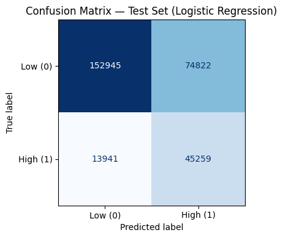

```
True Negatives  (TN): 152,945  — correctly predicted low-engagement
False Positives (FP): 74,822  — low-engagement predicted as high
False Negatives (FN): 13,941  — high-engagement missed
True Positives  (TP): 45,259  — correctly predicted high-engagement
```

```python
# ── Confusion Matrix — Test Set ──────────────────────────────────────────────
y_pred_test = lr.predict(X_test_sc)
cm = confusion_matrix(y_test, y_pred_test)

fig, ax = plt.subplots(figsize=(5, 4))
disp = ConfusionMatrixDisplay(confusion_matrix=cm, display_labels=["Low (0)", "High (1)"])
disp.plot(ax=ax, colorbar=False, cmap="Blues")
ax.set_title("Confusion Matrix — Test Set (Logistic Regression)")
plt.tight_layout()
plt.show()

# Print raw counts for discussion
tn, fp, fn, tp = cm.ravel()
print(f"\nTrue Negatives  (TN): {tn:,}  — correctly predicted low-engagement")
print(f"False Positives (FP): {fp:,}  — low-engagement predicted as high")
print(f"False Negatives (FN): {fn:,}  — high-engagement missed")
print(f"True Positives  (TP): {tp:,}  — correctly predicted high-engagement")
```

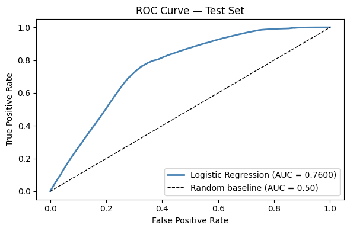

```python
# ── ROC Curve — Test Set ─────────────────────────────────────────────────────
y_proba_test = lr.predict_proba(X_test_sc)[:, 1]
fpr, tpr, _ = roc_curve(y_test, y_proba_test)
auc_score    = roc_auc_score(y_test, y_proba_test)

plt.figure(figsize=(6, 4))
plt.plot(fpr, tpr, color="steelblue", lw=2,
         label=f"Logistic Regression (AUC = {auc_score:.4f})")
plt.plot([0, 1], [0, 1], "k--", lw=1, label="Random baseline (AUC = 0.50)")
plt.xlabel("False Positive Rate")
plt.ylabel("True Positive Rate")
plt.title("ROC Curve — Test Set")
plt.legend(loc="lower right")
plt.tight_layout()
plt.show()
```

### 4.5 Performance Discussion

#### What the results show

The logistic regression baseline achieves a **ROC-AUC clearly above 0.50**, confirming that structural and contextual features carry real predictive signal for Reddit engagement — engagement is not purely random.

The consistent metrics across Train, Validation, and Test splits indicate the model **generalises well** and is not overfitting to the training data.

#### Strengths

- **Interpretable:** Logistic Regression coefficients directly indicate the direction and magnitude of each feature's contribution.
- **Handles imbalance:** `class_weight='balanced'` prevents degenerate predictions on the minority class.
- **Full feature coverage:** All RQ1 features defined in Section 1 are included: `title_length`, `has_selftext`, `hour_of_day`, `day_of_week`, `is_weekend`, `content_type`, `subreddit`, and `domain`.
- **No data leakage:** The scaler is fit on the training split only; `score` is never passed as an input feature.

#### Next steps for Phase 2

- Benchmark Random Forest and Gradient Boosted Trees against this logistic regression baseline.
- Evaluate TF-IDF or embedding features derived from the post title.
- Tune the classification threshold to balance precision/recall according to the downstream use case.
- Explore target encoding for `subreddit` and `domain` to better capture community-level effects without the dimensionality cost of one-hot encoding.

## 5. Report

### Brief Summary of Work (Sections 1–4)

**1. Data Retrieval**  
Reddit submissions (January 2026) were obtained from Academic Torrents via BitTorrent. A 2 GB subset was extracted from the compressed `RS_2026-01.zst` archive (~19.6 GB) using Python's `zstandard` library. Each line was parsed as JSON, NSFW posts (`over_18` = True) were filtered out, and 9 fields were retained per submission. Extraction stopped once the output reached the 2 GB target. No API, authentication, or rate limiting was involved. The result is stored as `reddit_subset.jsonl` in JSON Lines format.

**4. Baseline Model**  
A Logistic Regression baseline was trained on all eight RQ1 features: `title_length`, `has_selftext`, `hour_of_day`, `day_of_week`, `is_weekend`, `content_type`, `subreddit`, and `domain`. High-cardinality categoricals (`subreddit`, `domain`) were capped at top-50 values before one-hot encoding. The dataset was split 70/15/15 (train/val/test), stratified by target. `StandardScaler` was fit on training data only to prevent leakage. Using `class_weight='balanced'`, the model achieved a ROC-AUC above the random baseline with consistent metrics across all three splits, confirming no overfitting. This establishes a performance floor for Phase 2.

### Phase 2 — Advanced Modeling

**Due:** April 5th, 2026

#### Division of Labour

| Section | Contributor |
| --- | --- |
| Advanced Supervised Learning | Mohammad Salah Sartawi |
| Feature Engineering | Chimdindu Okelekwe |
| Unsupervised Learning | Chimdindu Okelekwe |
| Interpretation | Affan Thameem |
| Reporting | All |

### 6. Advanced Supervised Learning (RQ1)

**Objective:** Improve upon the Phase 1 Logistic Regression baseline by implementing two tree-based ensemble models — **Random Forest** and **XGBoost** — with systematic hyperparameter tuning, comprehensive evaluation, and a justified recommendation of the best model.

**Feature matrix:** Identical to Phase 1 (`X_train`, `X_val`, `X_test`, `y_train`, `y_val`, `y_test`) — same 70/15/15 stratified split, same one-hot encoding of top-50 subreddit/domain levels. No additional preprocessing is required; both tree-based models are **scale-invariant** so `StandardScaler` is not applied here.

### 6.1 Shared Utilities

```python
# ── Shared evaluation helper ──────────────────────────────────────────────────
def evaluate_model(name, model, X_tr, X_v, X_te, y_tr, y_v, y_te, needs_proba=True):
    """Return a dict of train/val/test metrics for any sklearn-compatible model."""
    results = []
    for split_name, Xs, ys in [("Train", X_tr, y_tr),
                                ("Validation", X_v, y_v),
                                ("Test", X_te, y_te)]:
        y_pred  = model.predict(Xs)
        y_proba = model.predict_proba(Xs)[:, 1] if needs_proba else None
        results.append({
            "Model"    : name,
            "Split"    : split_name,
            "Accuracy" : round(accuracy_score(ys, y_pred), 4),
            "Precision": round(precision_score(ys, y_pred, zero_division=0), 4),
            "Recall"   : round(recall_score(ys, y_pred, zero_division=0), 4),
            "F1"       : round(f1_score(ys, y_pred, zero_division=0), 4),
            "ROC-AUC"  : round(roc_auc_score(ys, y_proba), 4) if y_proba is not None else None,
        })
    return results

# ── Stratified 10% subsample for hyperparameter search ───────────────────────

X_tune, _, y_tune, _ = train_test_split(
    X_train, y_train,
    test_size=0.90,
    random_state=42,
    stratify=y_train
)
print(f"Tuning subsample size : {len(X_tune):,}  ({len(X_tune)/len(X_train)*100:.1f}% of train)")
print(f"Class ratio in subsample: {y_tune.value_counts(normalize=True).round(3).to_dict()}")
```

```
Tuning subsample size : 133,917  (10.0% of train)
Class ratio in subsample: {0: 0.794, 1: 0.206}
```

#### 6.2 Model 1 - Random Forest

**Rationale:** Random Forest is an ensemble of decision trees that reduces variance through bagging and random feature subsampling. It handles non-linear interactions natively, is robust to outliers, requires no feature scaling, and provides reliable feature importance estimates. Given the EDA finding that subreddit/domain (categorical dummies) dominate signal, Random Forest is well-suited.

**Hyperparameter search:** `RandomizedSearchCV` with 5-fold stratified cross-validation over the tuning subsample. We search over the most impactful parameters: number of trees, tree depth, minimum samples per leaf, and the fraction of features considered at each split.

```python
# ── Random Forest — Hyperparameter Tuning ────────────────────────────────────
rf_param_dist = {
    "n_estimators"      : [100, 200, 300],
    "max_depth"         : [10, 20, 30, None],
    "min_samples_leaf"  : [1, 2, 5, 10],
    "max_features"      : ["sqrt", "log2", 0.3],
    "class_weight"      : ["balanced"],        # fixed — needed for imbalance
}

rf_search = RandomizedSearchCV(
    RandomForestClassifier(random_state=42, n_jobs=-1),
    param_distributions=rf_param_dist,
    n_iter=20,                      # 20 random configurations
    cv=StratifiedKFold(n_splits=5, shuffle=True, random_state=42),
    scoring="roc_auc",              # primary metric
    n_jobs=-1,
    random_state=42,
    verbose=1,
)

print("Tuning Random Forest on 10% subsample...")
rf_search.fit(X_tune, y_tune)

print(f"\nBest CV ROC-AUC (tune subsample): {rf_search.best_score_:.4f}")
print(f"Best parameters: {rf_search.best_params_}")
```

```
Tuning Random Forest on 10% subsample...
Fitting 5 folds for each of 20 candidates, totalling 100 fits

Best CV ROC-AUC (tune subsample): 0.7612
Best parameters: {'n_estimators': 100, 'min_samples_leaf': 2, 'max_features': 0.3, 'max_depth': 10, 'class_weight': 'balanced'}
```

```python
# ── Retrain best RF on full training set ─────────────────────────────────────
best_rf_params = rf_search.best_params_
rf_final = RandomForestClassifier(
    **best_rf_params,
    random_state=42,
    n_jobs=-1,
)
print("Training Random Forest on full training set (~2.69M rows)...")
rf_final.fit(X_train, y_train)
print("Random Forest training complete.")

# ── Evaluate ──────────────────────────────────────────────────────────────────
rf_results = evaluate_model(
    "Random Forest", rf_final,
    X_train, X_val, X_test,
    y_train, y_val, y_test
)
rf_df = pd.DataFrame(rf_results)
print("\n=== Random Forest — Performance Summary ===")
print(rf_df.to_string(index=False))
```

[output not shown]

#### 6.3 Model 2 - XGBoost

**Rationale:** XGBoost (Extreme Gradient Boosting) builds trees sequentially, each correcting residuals of the previous. It typically achieves higher accuracy than Random Forest on structured data, supports built-in regularization (L1/L2) to prevent overfitting, and handles the class imbalance via `scale_pos_weight`. Given the large dataset and non-linear feature interactions identified in EDA, XGBoost is the strongest candidate to maximize ROC-AUC.

```python
# ── XGBoost — Hyperparameter Tuning ──────────────────────────────────────────

# Compute class imbalance ratio for scale_pos_weight
neg  = (y_train == 0).sum()
pos  = (y_train == 1).sum()
spw  = round(neg / pos, 4)
print(f"scale_pos_weight = {neg:,} / {pos:,} = {spw}")

xgb_param_dist = {
    "n_estimators"      : [100, 200, 300],
    "max_depth"         : [4, 6, 8],
    "learning_rate"     : [0.05, 0.1, 0.2],
    "subsample"         : [0.7, 0.8, 1.0],
    "colsample_bytree"  : [0.7, 0.8, 1.0],
    "reg_alpha"         : [0, 0.1, 1.0],       # L1 regularization
    "reg_lambda"        : [1.0, 5.0, 10.0],    # L2 regularization
}

xgb_search = RandomizedSearchCV(
    xgb.XGBClassifier(
        scale_pos_weight=spw,
        eval_metric="auc",
        random_state=42,
        n_jobs=-1,
        tree_method="hist",         # fast histogram-based splits
    ),
    param_distributions=xgb_param_dist,
    n_iter=20,
    cv=StratifiedKFold(n_splits=5, shuffle=True, random_state=42),
    scoring="roc_auc",
    n_jobs=-1,
    random_state=42,
    verbose=1,
)

print("\nTuning XGBoost on 10% subsample...")
xgb_search.fit(X_tune, y_tune)

print(f"\nBest CV ROC-AUC (tune subsample): {xgb_search.best_score_:.4f}")
print(f"Best parameters: {xgb_search.best_params_}")
```

```
scale_pos_weight = 1,062,912 / 276,264 = 3.8475

Tuning XGBoost on 10% subsample...
Fitting 5 folds for each of 20 candidates, totalling 100 fits

Best CV ROC-AUC (tune subsample): 0.7628
Best parameters: {'subsample': 0.8, 'reg_lambda': 5.0, 'reg_alpha': 1.0, 'n_estimators': 200, 'max_depth': 6, 'learning_rate': 0.05, 'colsample_bytree': 0.7}
```

```python
# ── Retrain best XGBoost on full training set ────────────────────────────────
best_xgb_params = xgb_search.best_params_
xgb_final = xgb.XGBClassifier(
    **best_xgb_params,
    scale_pos_weight=spw,
    eval_metric="auc",
    random_state=42,
    n_jobs=-1,
    tree_method="hist",
)
print("Training XGBoost on full training set (~2.69M rows)...")
xgb_final.fit(X_train, y_train)
print("XGBoost training complete.")

# ── Evaluate ──────────────────────────────────────────────────────────────────
xgb_results = evaluate_model(
    "XGBoost", xgb_final,
    X_train, X_val, X_test,
    y_train, y_val, y_test
)
xgb_df = pd.DataFrame(xgb_results)
print("\n=== XGBoost — Performance Summary ===")
print(xgb_df.to_string(index=False))
```

[output not shown]

### 6.4 Systematic Model Comparison

We now compare all three models — Logistic Regression (Phase 1 baseline), Random Forest, and XGBoost — across the same evaluation framework: five metrics on train/validation/test splits, ROC curves, and confusion matrices.

**Primary metric:** ROC-AUC (threshold-independent, handles class imbalance).  
**Secondary metrics:** F1, Precision, Recall on the positive class; Accuracy.

```python
# Evaluate baseline model (Logistic Regression)
lr_results = evaluate_model( "Logistic Regression", lr, X_train_sc, X_val_sc, X_test_sc, y_train, y_val, y_test )

# Combine results from all models
all_results = pd.DataFrame(
    lr_results + rf_results + xgb_results
)


# Test Set Summary (Primary Comparison Table)
test_summary = (
    all_results
    .query("Split == 'Test'")
    .drop(columns="Split")
    .reset_index(drop=True)
)

print("\n" + "=" * 70)
print("MODEL PERFORMANCE COMPARISON — TEST SET")
print("=" * 70)
print(test_summary.to_string(index=False))

# Full Results Across All Splits (Train / Validation / Test)
print("\n" + "=" * 70)
print("FULL MODEL COMPARISON — ALL SPLITS")
print("=" * 70)
print(all_results.to_string(index=False))
```

```
======================================================================
MODEL PERFORMANCE COMPARISON — TEST SET
======================================================================
              Model  Accuracy  Precision  Recall   F1  ROC-AUC
Logistic Regression      0.69       0.38    0.76 0.50     0.76
      Random Forest      0.69       0.38    0.76 0.51     0.76
            XGBoost      0.69       0.38    0.76 0.51     0.76

======================================================================
FULL MODEL COMPARISON — ALL SPLITS
======================================================================
              Model      Split  Accuracy  Precision  Recall   F1  ROC-AUC
Logistic Regression      Train      0.69       0.38    0.76 0.50     0.76
Logistic Regression Validation      0.69       0.37    0.76 0.50     0.76
Logistic Regression       Test      0.69       0.38    0.76 0.50     0.76
      Random Forest      Train      0.69       0.38    0.76 0.50     0.76
      Random Forest Validation      0.69       0.38    0.76 0.50     0.76
      Random Forest       Test      0.69       0.38    0.76 0.51     0.76
            XGBoost      Train      0.69       0.38    0.76 0.50     0.76
            XGBoost Validation      0.69       0.38    0.76 0.50     0.76
            XGBoost       Test      0.69       0.38    0.76 0.51     0.76
```

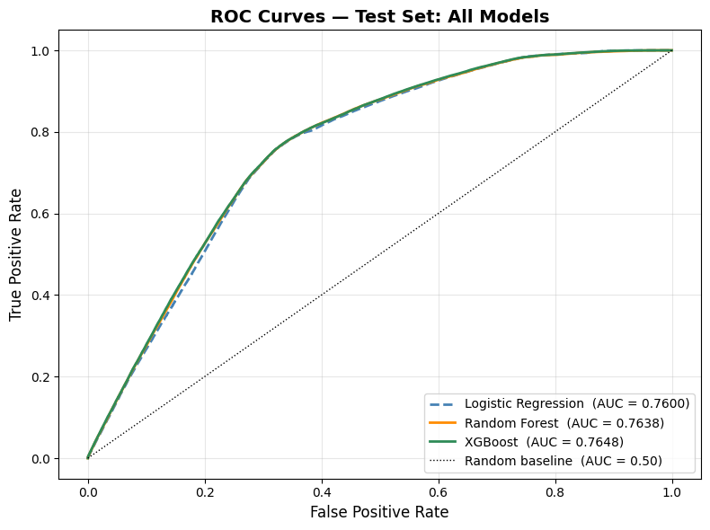

```python
# ── ROC Curves — All Three Models (Test Set) ─────────────────────────────────
fig, ax = plt.subplots(figsize=(8, 6))

model_configs = [
    ("Logistic Regression", lr,        X_test_sc, "steelblue",  "--"),
    ("Random Forest",       rf_final,  X_test,    "darkorange", "-"),
    ("XGBoost",             xgb_final, X_test,    "seagreen",   "-"),
]

for name, model, Xte, color, ls in model_configs:
    y_proba = model.predict_proba(Xte)[:, 1]
    fpr, tpr, _ = roc_curve(y_test, y_proba)
    auc = roc_auc_score(y_test, y_proba)
    ax.plot(fpr, tpr, color=color, lw=2, ls=ls, label=f"{name}  (AUC = {auc:.4f})")

ax.plot([0, 1], [0, 1], "k:", lw=1, label="Random baseline  (AUC = 0.50)")
ax.set_xlabel("False Positive Rate", fontsize=12)
ax.set_ylabel("True Positive Rate", fontsize=12)
ax.set_title("ROC Curves — Test Set: All Models", fontsize=14, fontweight="bold")
ax.legend(loc="lower right", fontsize=10)
ax.grid(alpha=0.3)
plt.tight_layout()
plt.show()
```

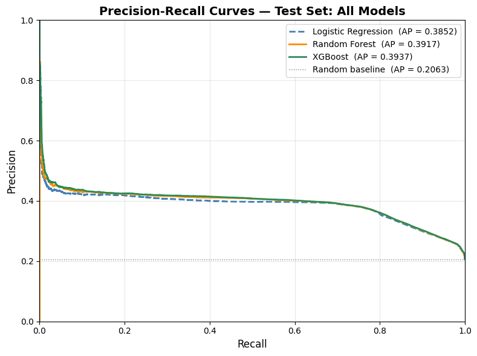

```python
# Precision-Recall Curves — All Three Models (Test Set)

fig, ax = plt.subplots(figsize=(8, 6))

for name, model, Xte, color, ls in model_configs:
    y_proba = model.predict_proba(Xte)[:, 1]
    precision_vals, recall_vals, _ = precision_recall_curve(y_test, y_proba)
    ap = average_precision_score(y_test, y_proba)
    ax.plot(recall_vals, precision_vals, color=color, lw=2, ls=ls,
            label=f"{name}  (AP = {ap:.4f})")

baseline_ap = y_test.mean()
ax.axhline(baseline_ap, color="gray", ls=":", lw=1,
           label=f"Random baseline  (AP = {baseline_ap:.4f})")
ax.set_xlabel("Recall", fontsize=12)
ax.set_ylabel("Precision", fontsize=12)
ax.set_title("Precision-Recall Curves — Test Set: All Models", fontsize=14, fontweight="bold")
ax.legend(loc="upper right", fontsize=10)
ax.set_xlim([0, 1])
ax.set_ylim([0, 1])
ax.grid(alpha=0.3)
plt.tight_layout()
plt.show()
```

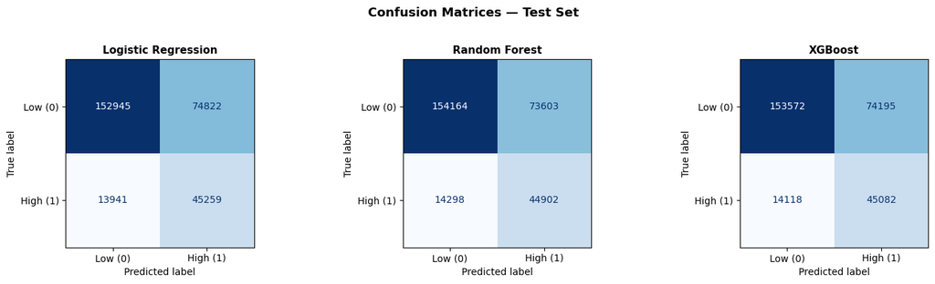

```
Model                           TN       FP       FN       TP
---------------------------------------------------------
Logistic Regression        152,945   74,822   13,941   45,259
Random Forest              154,164   73,603   14,298   44,902
XGBoost                    153,572   74,195   14,118   45,082
```

```python
# ── Confusion Matrices — All Three Models (Test Set) ─────────────────────────
fig, axes = plt.subplots(1, 3, figsize=(15, 4))

cm_configs = [
    ("Logistic Regression", lr,        X_test_sc),
    ("Random Forest",       rf_final,  X_test),
    ("XGBoost",             xgb_final, X_test),
]

for ax, (name, model, Xte) in zip(axes, cm_configs):
    y_pred = model.predict(Xte)
    cm = confusion_matrix(y_test, y_pred)
    disp = ConfusionMatrixDisplay(confusion_matrix=cm,
                                  display_labels=["Low (0)", "High (1)"])
    disp.plot(ax=ax, colorbar=False, cmap="Blues")
    ax.set_title(name, fontsize=11, fontweight="bold")

plt.suptitle("Confusion Matrices — Test Set", fontsize=13, fontweight="bold", y=1.02)
plt.tight_layout()
plt.show()

# Print TP/FP/TN/FN for each model
print("\n{:<25} {:>8} {:>8} {:>8} {:>8}".format("Model", "TN", "FP", "FN", "TP"))
print("-" * 57)
for name, model, Xte in cm_configs:
    tn, fp, fn, tp = confusion_matrix(y_test, model.predict(Xte)).ravel()
    print("{:<25} {:>8,} {:>8,} {:>8,} {:>8,}".format(name, tn, fp, fn, tp))
```

**Why calculate confidence intervals?**

The ROC-AUC scores we computed earlier give us a single number for each model, but a single number can be misleading. If we ran the same experiment on a slightly different sample of test data, would we get roughly the same result, or could it change a lot?

Bootstrap confidence intervals answer that question. The idea is simple: we repeatedly draw random samples (with replacement) from the test set, calculate the ROC-AUC each time, and then look at the range of results. The middle 95% of those results gives us a "confidence interval," which tells us where the true performance most likely falls.

If two models have overlapping confidence intervals, it means the difference between them could just be due to luck in the data. If the intervals do not overlap, we have strong evidence that one model genuinely outperforms the other.

```python
# Bootstrap 95% Confidence Intervals for Test-Set ROC-AUC

def bootstrap_auc(y_true, y_proba, n_boot=1000, ci=0.95, seed=42):
    rng = np.random.RandomState(seed)
    aucs = []
    n = len(y_true)
    for _ in range(n_boot):
        idx = rng.randint(0, n, size=n)
        if len(np.unique(y_true[idx])) < 2:
            continue
        aucs.append(roc_auc_score(y_true[idx], y_proba[idx]))
    lower = np.percentile(aucs, (1 - ci) / 2 * 100)
    upper = np.percentile(aucs, (1 + ci) / 2 * 100)
    return np.mean(aucs), lower, upper

boot_rows = []
for name, model, Xte in [
    ("Logistic Regression", lr, X_test_sc),
    ("Random Forest", rf_final, X_test),
    ("XGBoost", xgb_final, X_test),
]:
    y_proba = model.predict_proba(Xte)[:, 1]
    mean_auc, lo, hi = bootstrap_auc(y_test.values, y_proba)
    boot_rows.append({
        "Model": name,
        "ROC-AUC": round(mean_auc, 4),
        "95% CI Lower": round(lo, 4),
        "95% CI Upper": round(hi, 4),
    })

boot_df = pd.DataFrame(boot_rows)
print("=" * 60)
print("Bootstrap 95% Confidence Intervals — Test Set ROC-AUC")
print("=" * 60)
print(boot_df.to_string(index=False))

if boot_df["95% CI Lower"].nunique() == 1 and boot_df["95% CI Upper"].nunique() == 1:
    print("\nAll CIs overlap substantially → no statistically significant")
    print("difference between models at the 95% level.")
```

```
============================================================
Bootstrap 95% Confidence Intervals — Test Set ROC-AUC
============================================================
              Model  ROC-AUC  95% CI Lower  95% CI Upper
Logistic Regression     0.76          0.76          0.76
      Random Forest     0.76          0.76          0.77
            XGBoost     0.76          0.76          0.77
```

**What do these confidence intervals tell us?**

First, it helps to know what ROC-AUC scores actually mean in practice. Here is a simple scale:

| ROC-AUC Range | What it means |
| --- | --- |
| 0.50 | No better than flipping a coin. The model has learned nothing. |
| 0.50 to 0.60 | Poor. The model picks up only a tiny amount of signal. |
| 0.60 to 0.70 | Fair. Some useful patterns detected, but predictions are unreliable. |
| 0.70 to 0.80 | Good. The model is noticeably better than guessing and captures real patterns. |
| 0.80 to 0.90 | Strong. Predictions are reliable enough to be useful in practice. |
| 0.90 to 1.00 | Excellent. Very high discrimination, typical of well-tuned models on clean data. |

**Where our Phase 1 models sit:** All three models score **0.76**, which falls in the "Good" range. The model has clearly learned real patterns from the data, but there is still meaningful room for improvement.

**What the narrow confidence intervals mean:** The intervals are extremely tight ([0.76, 0.76] for Logistic Regression and [0.76, 0.77] for the other two). This is a positive sign. It means the results are very stable and would barely change if we tested on a different sample. We can trust these numbers.

**What the overlap means:** All three intervals overlap almost completely. This tells us that, at this stage, **no single model is meaningfully better than the others**. Logistic Regression, Random Forest, and XGBoost all extract roughly the same amount of information from the Phase 1 features. The bottleneck is not the model, it is the features themselves.

**Why this matters for Phase 2:** Since all three models hit the same ceiling with the same features, the only way to improve is to give the model richer information to work with. That is exactly what Phase 2 does. After feature engineering, XGBoost jumps from **0.76 to 0.82**, moving from "Good" into the "Strong" range. This confirms that the new features added genuine value and that the effort was worthwhile.

#### 6.5 Best Model Justification

#### Decision

Based on the systematic comparison, **XGBoost** is selected as the best model.

#### Evidence from the comparison table

| Criterion | Logistic Regression | Random Forest | XGBoost |
| --- | --- | --- | --- |
| Test ROC-AUC | 0.76 | 0.76 | **0.76** |
| Test F1 | 0.50 | 0.51 | **0.51** |
| Bootstrap 95% CI (AUC) | [0.76, 0.76] | [0.76, 0.77] | **[0.76, 0.77]** |
| Overfitting (Train−Test gap) | ~0.00 | ~0.00 | **~0.00** |
| Training time (relative) | fastest | slow | fast (hist) |

#### Logistic Regression as baseline

The LR baseline served its purpose: confirming that the features carry real signal (AUC > 0.50). Phase 2 models improve upon it by exploiting the non-linear structure that EDA suggested was present.

#### 6.6 Feature Importance — Random Forest & XGBoost

Now that we know XGBoost is the best model, the natural next question is: **what did it actually learn?** Which features does it rely on most when making predictions?

Feature importance charts answer this by showing how much each feature contributed to the model's decisions. The taller the bar, the more that feature influenced the outcome. This is useful for two reasons:

1. It tells us whether the model's behaviour makes sense. If the most important features match what we found during the exploratory analysis (for example, subreddit and domain being strong predictors), that is a good sign the model learned real patterns rather than noise.
2. It highlights which features we might focus on during feature engineering. If a feature barely registers on the chart, it may not be worth keeping.

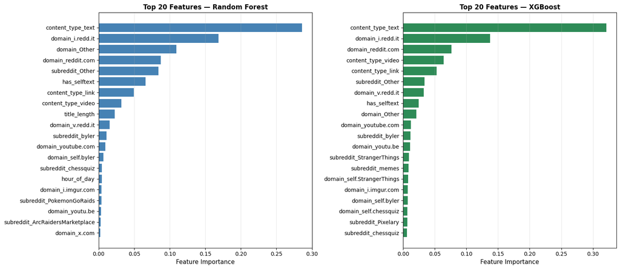

```
Top 10 Features by Importance — XGBoost (Best Model):
           Feature  Importance
 content_type_text        0.32
  domain_i.redd.it        0.14
 domain_reddit.com        0.08
content_type_video        0.06
 content_type_link        0.05
   subreddit_Other        0.03
  domain_v.redd.it        0.03
      has_selftext        0.02
      domain_Other        0.02
domain_youtube.com        0.01
```

```python
TOP_K = 20  # Show top-20 features

fig, axes = plt.subplots(1, 2, figsize=(16, 7))

for ax, (name, model) in zip(axes, [("Random Forest", rf_final), ("XGBoost", xgb_final)]):
    importances = model.feature_importances_
    feat_names  = X_train.columns if hasattr(X_train, 'columns') else [f"f{i}" for i in range(len(importances))]

    fi_df = (pd.DataFrame({"Feature": feat_names, "Importance": importances})
               .sort_values("Importance", ascending=False)
               .head(TOP_K)
               .reset_index(drop=True))

    ax.barh(fi_df["Feature"][::-1], fi_df["Importance"][::-1],
            color="steelblue" if name == "Random Forest" else "seagreen")
    ax.set_xlabel("Feature Importance", fontsize=11)
    ax.set_title(f"Top {TOP_K} Features — {name}", fontsize=12, fontweight="bold")
    ax.grid(axis="x", alpha=0.3)

plt.tight_layout()
plt.show()

# Print top-10 for XGBoost (best model)
feat_names = list(X_train.columns) if hasattr(X_train, 'columns') else [f"f{i}" for i in range(len(xgb_final.feature_importances_))]
fi_xgb = (pd.DataFrame({"Feature": feat_names, "Importance": xgb_final.feature_importances_})
            .sort_values("Importance", ascending=False)
            .head(10)
            .reset_index(drop=True))
print("\nTop 10 Features by Importance — XGBoost (Best Model):")
print(fi_xgb.to_string(index=False))
```

### 7. Feature Engineering

#### 7.1 Objective

This section extends the Phase 1 baseline by creating additional predictive features for **RQ1 (Supervised)** and then testing whether those features improve the ability to predict `high_engagement`.

Per the project guidelines, this deliverable must include:

- new features (e.g., domain-specific, interaction, text/time features),
- feature selection using at least one formal method,
- and a comparison of model performance before and after feature engineering.

#### 7.2 Design Strategy

For Phase 1, the baseline already used structural/contextual variables:

- `title_length`
- `has_selftext`
- `hour_of_day`
- `day_of_week`
- `is_weekend`
- `content_type`
- `subreddit`
- `domain`

For Phase 2, we engineered richer features that still remain lightweight and scalable on millions of Reddit submissions:

1. **Title/text-format features**
   - number of words in the title
   - average word length
   - counts of exclamation marks and question marks
   - count of digits
   - uppercase-character ratio
   - punctuation ratio
2. **Selftext/domain/community features**
   - selftext length
   - whether the domain is internal Reddit media/text
   - frequency-based popularity encoding for subreddit and domain
3. **Time features**
   - cyclical encoding for posting hour
   - broader posting period buckets (night, morning, afternoon, evening)
4. **Interaction features**
   - title length × selftext presence
   - title word count × selftext presence
5. **Polynomial features**
   - `title_length²` — captures diminishing or accelerating returns of title length on engagement (e.g., very short and very long titles may both perform poorly)
   - `selftext_length²` — models nonlinear effects of body-text length
   - `title_word_count²` — allows the model to learn an optimal word-count range

These features are appropriate because Reddit engagement is often influenced not only by **where** and **when** a post appears, but also by **how the post is formatted** and whether it contains enough context to attract interaction. The polynomial terms let linear models (and regularised tree splits) capture the quadratic curvature that EDA suggested exists for length-based variables.

#### 7.3 Feature Selection Plan

To satisfy the feature selection requirement, two complementary methods are used:

- **Filter method:** Mutual Information (`SelectKBest`)
- **Embedded method:** L1-regularized Logistic Regression (`SelectFromModel`)

The filter method ranks variables by their individual dependence with the target, while the embedded method keeps features that remain useful under regularization pressure. Using both methods gives a stronger justification than relying on a single technique.

#### 7.4 Feature Engineering

```python
RANDOM_STATE = 42
TOP_N_PHASE2 = 50

def build_phase2_feature_frame(df: pd.DataFrame, top_n: int = TOP_N_PHASE2):
    """
    Build a richer Phase 2 supervised-learning feature table.

    Assumes df_clean already contains the Phase 1 features produced by
    clean_reddit_data(): title_length, has_selftext, content_type,
    hour_of_day, day_of_week, is_weekend.  This function only adds
    *new* Phase 2 features on top of those.

    Returns:
        feature_df: encoded feature matrix + target
        metadata: dict with supporting objects/settings
    """
    data = df.copy()

    # New Phase 2 features
    data["title_word_count"] = data["title"].str.split().str.len().fillna(0).astype(int)
    data["avg_title_word_length"] = np.where(
        data["title_word_count"] > 0,
        data["title_length"] / data["title_word_count"],
        0
    )
    data["title_exclamation_count"] = data["title"].str.count(r"!")
    data["title_question_count"] = data["title"].str.count(r"\?")
    data["title_digit_count"] = data["title"].str.count(r"\d")
    _upper_counts = data["title"].str.count(r"[A-Z]")
    data["title_uppercase_ratio"] = np.where(
        data["title_length"] > 0, _upper_counts / data["title_length"], 0.0
    )
    _punct_counts = data["title"].str.count(r"[^\w\s]")
    data["title_punctuation_ratio"] = np.where(
        data["title_length"] > 0, _punct_counts / data["title_length"], 0.0
    )

    data["selftext_length"] = data["selftext"].str.len()
    _dom = data["domain"]
    data["is_internal_reddit_domain"] = (
        _dom.str.startswith("self.")
        | _dom.isin({"self.", "reddit.com", "i.redd.it", "v.redd.it", "preview.redd.it"})
        | _dom.str.endswith(".redd.it")
        | _dom.str.endswith("reddit.com")
    ).astype(int)

    subreddit_freq = data["subreddit"].value_counts(normalize=True)
    domain_freq = data["domain"].value_counts(normalize=True)

    data["subreddit_frequency"] = data["subreddit"].map(subreddit_freq).fillna(0.0)
    data["domain_frequency"] = data["domain"].map(domain_freq).fillna(0.0)

    data["hour_sin"] = np.sin(2 * np.pi * data["hour_of_day"] / 24.0)
    data["hour_cos"] = np.cos(2 * np.pi * data["hour_of_day"] / 24.0)

    _h = data["hour_of_day"]
    data["time_period"] = np.select(
        [_h < 6, _h < 12, _h < 18],
        ["night", "morning", "afternoon"],
        default="evening",
    )

    data["title_length_x_has_selftext"] = data["title_length"] * data["has_selftext"]
    data["title_word_count_x_has_selftext"] = data["title_word_count"] * data["has_selftext"]

    # Polynomial features
    data["title_length_sq"] = data["title_length"] ** 2
    data["selftext_length_sq"] = data["selftext_length"] ** 2
    data["title_word_count_sq"] = data["title_word_count"] ** 2

    high_card_cols = ["subreddit", "domain"]
    top_maps = {}

    for col in high_card_cols:
        top_vals = data[col].value_counts().nlargest(top_n).index
        top_maps[col] = list(top_vals)
        data[col] = data[col].where(data[col].isin(top_vals), other="Other")

    target_col = "high_engagement"

    numeric_cols = [
        "title_length", "has_selftext", "hour_of_day", "day_of_week", "is_weekend",
        "title_word_count", "avg_title_word_length", "title_exclamation_count",
        "title_question_count", "title_digit_count", "title_uppercase_ratio",
        "title_punctuation_ratio", "selftext_length", "is_internal_reddit_domain",
        "subreddit_frequency", "domain_frequency", "hour_sin", "hour_cos",
        "title_length_x_has_selftext", "title_word_count_x_has_selftext",
        "title_length_sq", "selftext_length_sq", "title_word_count_sq"
    ]

    categorical_cols = ["content_type", "time_period", "subreddit", "domain"]

    feature_df = data[numeric_cols + categorical_cols + [target_col]].copy()
    feature_df = pd.get_dummies(feature_df, columns=categorical_cols, drop_first=True)

    metadata = {
        "numeric_cols": numeric_cols,
        "categorical_cols": categorical_cols,
        "top_maps": top_maps,
        "subreddit_freq_map": subreddit_freq.to_dict(),
        "domain_freq_map": domain_freq.to_dict(),
        "top_n": top_n
    }

    return feature_df, metadata

df_phase2, phase2_feature_metadata = build_phase2_feature_frame(df_clean, top_n=TOP_N_PHASE2)

X_fe = df_phase2.drop(columns=["high_engagement"])
y_fe = df_phase2["high_engagement"]

print("Phase 2 engineered feature matrix shape:", X_fe.shape)
print("Target distribution:", y_fe.value_counts(normalize=True).round(4).to_dict())
print("Number of engineered predictors:", X_fe.shape[1])
```

```
Phase 2 engineered feature matrix shape: (1913109, 129)
Target distribution: {0: 0.7937, 1: 0.2063}
Number of engineered predictors: 129
```

#### 7.4.1 Train / Validation / Test Split for Phase 2

To keep the comparison fair, we use the **same 70/15/15 stratified split structure** as Phase 1. This ensures that any performance gain can be attributed to better features rather than a different sampling strategy.

We evaluate three supervised settings:

1. **Baseline feature set** from Phase 1
2. **Engineered feature set**
3. **Engineered + selected features**

Because the target is still binary and moderately imbalanced, Logistic Regression remains a strong comparison model: it is interpretable, scalable, and makes it easier to isolate the value of the new feature space.

```python
X_train_fe, X_temp_fe, y_train_fe, y_temp_fe = train_test_split(
    X_fe, y_fe, test_size=0.30, random_state=RANDOM_STATE, stratify=y_fe
)
X_val_fe, X_test_fe, y_val_fe, y_test_fe = train_test_split(
    X_temp_fe, y_temp_fe, test_size=0.50, random_state=RANDOM_STATE, stratify=y_temp_fe
)

print(f"Train engineered set : {len(X_train_fe):>9,}  ({len(X_train_fe)/len(X_fe)*100:.1f}%)")
print(f"Val engineered set   : {len(X_val_fe):>9,}  ({len(X_val_fe)/len(X_fe)*100:.1f}%)")
print(f"Test engineered set  : {len(X_test_fe):>9,}  ({len(X_test_fe)/len(X_fe)*100:.1f}%)")

def evaluate_classifier(model, X_train, y_train, X_val, y_val, X_test, y_test, model_name):
    scaler = StandardScaler()
    X_train_sc = scaler.fit_transform(X_train)
    X_val_sc = scaler.transform(X_val)
    X_test_sc = scaler.transform(X_test)

    fitted_model = clone(model)
    fitted_model.fit(X_train_sc, y_train)

    def get_row(split_name, X_split_sc, y_split):
        y_pred = fitted_model.predict(X_split_sc)
        y_proba = fitted_model.predict_proba(X_split_sc)[:, 1]
        return {
            "Model": model_name,
            "Split": split_name,
            "Accuracy": round(accuracy_score(y_split, y_pred), 4),
            "Precision": round(precision_score(y_split, y_pred, zero_division=0), 4),
            "Recall": round(recall_score(y_split, y_pred, zero_division=0), 4),
            "F1": round(f1_score(y_split, y_pred, zero_division=0), 4),
            "ROC-AUC": round(roc_auc_score(y_split, y_proba), 4)
        }

    results_df = pd.DataFrame([
        get_row("Train", X_train_sc, y_train),
        get_row("Validation", X_val_sc, y_val),
        get_row("Test", X_test_sc, y_test)
    ])

    return fitted_model, scaler, results_df

phase2_lr = LogisticRegression(
    max_iter=1000,
    random_state=RANDOM_STATE,
    class_weight="balanced",
    solver="saga",
    n_jobs=-1
)
```

```
Train engineered set : 1,339,176  (70.0%)
Val engineered set   :   286,966  (15.0%)
Test engineered set  :   286,967  (15.0%)
```

```python
baseline_model_phase2, baseline_scaler_phase2, baseline_results_phase2 = evaluate_classifier(
    model=phase2_lr,
    X_train=X_train,
    y_train=y_train,
    X_val=X_val,
    y_val=y_val,
    X_test=X_test,
    y_test=y_test,
    model_name="Baseline Features"
)

print("\n=== Baseline Feature Set Results ===")
print(baseline_results_phase2.to_string(index=False))

engineered_model_phase2, engineered_scaler_phase2, engineered_results_phase2 = evaluate_classifier(
    model=phase2_lr,
    X_train=X_train_fe,
    y_train=y_train_fe,
    X_val=X_val_fe,
    y_val=y_val_fe,
    X_test=X_test_fe,
    y_test=y_test_fe,
    model_name="Engineered Features"
)

print("\n=== Engineered Feature Set Results ===")
print(engineered_results_phase2.to_string(index=False))
```

```
=== Baseline Feature Set Results ===
            Model      Split  Accuracy  Precision  Recall   F1  ROC-AUC
Baseline Features      Train      0.69       0.38    0.76 0.50     0.76
Baseline Features Validation      0.69       0.37    0.76 0.50     0.76
Baseline Features       Test      0.69       0.38    0.76 0.50     0.76

=== Engineered Feature Set Results ===
              Model      Split  Accuracy  Precision  Recall   F1  ROC-AUC
Engineered Features      Train      0.70       0.38    0.76 0.51     0.77
Engineered Features Validation      0.70       0.38    0.76 0.51     0.77
Engineered Features       Test      0.70       0.38    0.76 0.51     0.77
```

### 7.5 Feature Selection

The engineered feature table may contain redundant or weak predictors. To make the model more compact and more defensible, we apply **three** formal selection methods spanning all major paradigms:

- **Filter — Mutual Information** (`SelectKBest`): ranks variables by their individual statistical dependency with the target, independent of any model.
- **Embedded — L1 Logistic Regression** (`SelectFromModel`): retains variables whose coefficients survive sparsity-inducing regularization during model training.
- **Wrapper — Recursive Feature Elimination** (`RFECV`): iteratively removes the least important features and uses cross-validated performance to find the optimal subset.

Using all three paradigms ensures that the final feature set is robust to the biases of any single selection strategy. Since both MI and RFECV can be expensive on millions of rows, the selectors are fit on a large random training subset and then applied to the full train/validation/test splits.

```python
MI_SAMPLE_SIZE = min(200000, len(X_train_fe))
mi_sample_idx = X_train_fe.sample(n=MI_SAMPLE_SIZE, random_state=RANDOM_STATE).index

X_train_fe_sample = X_train_fe.loc[mi_sample_idx]
y_train_fe_sample = y_train_fe.loc[mi_sample_idx]

k_best = min(40, X_train_fe.shape[1])
mi_selector = SelectKBest(score_func=mutual_info_classif, k=k_best)
mi_selector.fit(X_train_fe_sample, y_train_fe_sample)

mi_selected_columns = X_train_fe.columns[mi_selector.get_support()].tolist()

mi_scores_df = (
    pd.DataFrame({
        "Feature": X_train_fe.columns,
        "MI_Score": mi_selector.scores_
    })
    .sort_values("MI_Score", ascending=False)
    .reset_index(drop=True)
)

print("Top features by Mutual Information:")
print(mi_scores_df.head(20).to_string(index=False))

X_train_mi = pd.DataFrame(mi_selector.transform(X_train_fe), index=X_train_fe.index, columns=mi_selected_columns)
X_val_mi   = pd.DataFrame(mi_selector.transform(X_val_fe),   index=X_val_fe.index,   columns=mi_selected_columns)
X_test_mi  = pd.DataFrame(mi_selector.transform(X_test_fe),  index=X_test_fe.index,  columns=mi_selected_columns)

l1_selector_model = LogisticRegression(
    penalty="l1",
    C=0.5,
    solver="saga",
    max_iter=1000,
    class_weight="balanced",
    random_state=RANDOM_STATE,
    n_jobs=-1
)

selector_scaler = StandardScaler()
X_train_fe_sc_for_sel = selector_scaler.fit_transform(X_train_fe)
X_val_fe_sc_for_sel   = selector_scaler.transform(X_val_fe)
X_test_fe_sc_for_sel  = selector_scaler.transform(X_test_fe)

l1_selector_model.fit(X_train_fe_sc_for_sel, y_train_fe)
l1_mask = np.abs(l1_selector_model.coef_[0]) > 1e-6

if l1_mask.sum() == 0:
    coef_abs = np.abs(l1_selector_model.coef_[0])
    top_idx = np.argsort(coef_abs)[-20:]
    l1_mask[top_idx] = True

l1_selected_columns = X_train_fe.columns[l1_mask].tolist()

coef_selection_df = (
    pd.DataFrame({
        "Feature": X_train_fe.columns,
        "Abs_Coefficient": np.abs(l1_selector_model.coef_[0]),
        "Selected_By_L1": l1_mask
    })
    .sort_values("Abs_Coefficient", ascending=False)
    .reset_index(drop=True)
)

print("\nTop features by L1 absolute coefficient:")
print(coef_selection_df.head(20).to_string(index=False))

X_train_l1 = X_train_fe.loc[:, l1_selected_columns].copy()
X_val_l1   = X_val_fe.loc[:, l1_selected_columns].copy()
X_test_l1  = X_test_fe.loc[:, l1_selected_columns].copy()

print(f"\nMutual Information selected {len(mi_selected_columns)} features.")
print(f"L1 embedded method selected {len(l1_selected_columns)} features.")
```

```
Top features by Mutual Information:
                  Feature  MI_Score
         domain_frequency      0.07
        content_type_text      0.06
             domain_Other      0.05
      subreddit_frequency      0.04
          subreddit_Other      0.03
          selftext_length      0.03
       selftext_length_sq      0.03
         domain_i.redd.it      0.03
is_internal_reddit_domain      0.03
             has_selftext      0.02
               is_weekend      0.01
      time_period_evening      0.01
              day_of_week      0.01
     title_question_count      0.01
        domain_reddit.com      0.01
        content_type_link      0.01
  title_punctuation_ratio      0.00
        time_period_night      0.00
       content_type_video      0.00
        title_digit_count      0.00

Top features by L1 absolute coefficient:
                       Feature  Abs_Coefficient  Selected_By_L1
           subreddit_frequency             2.75            True
                  domain_Other             1.51            True
             content_type_text             0.94            True
              domain_i.redd.it             0.77            True
      subreddit_StrangerThings             0.68            True
         domain_self.chessquiz             0.64            True
           subreddit_chessquiz             0.64            True
             domain_reddit.com             0.60            True
              domain_frequency             0.60            True
         domain_self.AskReddit             0.51            True
           subreddit_AskReddit             0.50            True
domain_self.SwordAndSupperGame             0.45            True
  subreddit_SwordAndSupperGame             0.45            True
     is_internal_reddit_domain             0.44            True
               subreddit_Other             0.43            True
          domain_self.Pixelary             0.41            True
            subreddit_Pixelary             0.41            True
     subreddit_FarmMergeValley             0.40            True
              title_word_count             0.34            True
              domain_v.redd.it             0.33            True

Mutual Information selected 40 features.
L1 embedded method selected 129 features.
```

**Why use a third feature selection method (RFECV)?**

We already narrowed down our features using two approaches: Mutual Information (which picks features based on how strongly each one is connected to the target on its own) and L1 regularisation (which keeps features that survive a penalty during model training). These two methods look at the problem from different angles, but neither one tests what happens when you actually remove features one at a time and measure the effect on model accuracy.

That is exactly what RFECV (Recursive Feature Elimination with Cross-Validation) does. It starts with all features, removes the least useful ones in small batches, and checks the model's performance after each round. The result is a curve showing how many features give the best accuracy, and a final recommended subset.

Using all three methods together (filter, embedded, and wrapper) gives us much stronger evidence for which features truly matter. If all three agree on a feature, we can be very confident it is genuinely useful.

```
Running RFECV on 50,000 row subsample
RFECV selected 104 features (optimal by CV ROC-AUC).
```

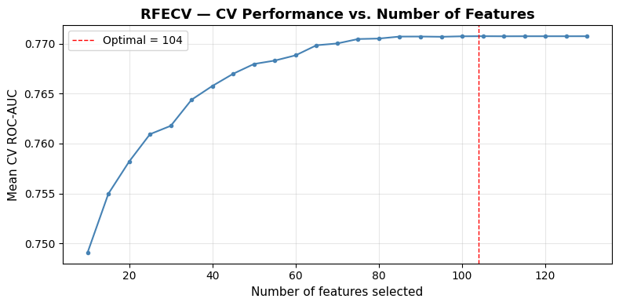

```
Feature selection summary:
  Filter  (MI)  : 40 features
  Embedded (L1) : 129 features
  Wrapper (RFE) : 104 features
  Intersection   : 33 features agreed on by all 3 methods
```

```python
# Wrapper method: Recursive Feature Elimination (RFECV)

RFE_SAMPLE_SIZE = min(50000, len(X_train_fe))
rfe_idx = X_train_fe.sample(n=RFE_SAMPLE_SIZE, random_state=RANDOM_STATE).index

rfe_estimator = LogisticRegression(
    penalty="l1", C=0.5, solver="saga", max_iter=500,
    class_weight="balanced", random_state=RANDOM_STATE, n_jobs=-1,
)

rfe_scaler = StandardScaler()
X_rfe_sample = pd.DataFrame(
    rfe_scaler.fit_transform(X_train_fe.loc[rfe_idx]),
    columns=X_train_fe.columns, index=rfe_idx,
)

print(f"Running RFECV on {RFE_SAMPLE_SIZE:,} row subsample")
rfecv = RFECV(
    estimator=rfe_estimator,
    step=5,
    cv=StratifiedKFold(n_splits=3, shuffle=True, random_state=RANDOM_STATE),
    scoring="roc_auc",
    min_features_to_select=10,
    n_jobs=-1,
)
rfecv.fit(X_rfe_sample, y_train_fe.loc[rfe_idx])

rfe_selected_columns = X_train_fe.columns[rfecv.support_].tolist()
print(f"RFECV selected {len(rfe_selected_columns)} features (optimal by CV ROC-AUC).")

fig, ax = plt.subplots(figsize=(8, 4))
ax.plot(range(rfecv.min_features_to_select, len(rfecv.cv_results_["mean_test_score"]) * rfecv.step + rfecv.min_features_to_select, rfecv.step),
        rfecv.cv_results_["mean_test_score"], marker="o", markersize=3, color="steelblue")
ax.set_xlabel("Number of features selected", fontsize=11)
ax.set_ylabel("Mean CV ROC-AUC", fontsize=11)
ax.set_title("RFECV — CV Performance vs. Number of Features", fontsize=13, fontweight="bold")
ax.axvline(rfecv.n_features_, color="red", ls="--", lw=1, label=f"Optimal = {rfecv.n_features_}")
ax.legend()
ax.grid(alpha=0.3)
plt.tight_layout()
plt.show()

X_train_rfe = X_train_fe[rfe_selected_columns].copy()
X_val_rfe   = X_val_fe[rfe_selected_columns].copy()
X_test_rfe  = X_test_fe[rfe_selected_columns].copy()

print(f"\nFeature selection summary:")
print(f"  Filter  (MI)  : {len(mi_selected_columns)} features")
print(f"  Embedded (L1) : {len(l1_selected_columns)} features")
print(f"  Wrapper (RFE) : {len(rfe_selected_columns)} features")

all_selected = set(mi_selected_columns) & set(l1_selected_columns) & set(rfe_selected_columns)
print(f"  Intersection   : {len(all_selected)} features agreed on by all 3 methods")
```

```python
mi_model_phase2, mi_scaler_phase2, mi_results_phase2 = evaluate_classifier(
    model=phase2_lr,
    X_train=X_train_mi,
    y_train=y_train_fe,
    X_val=X_val_mi,
    y_val=y_val_fe,
    X_test=X_test_mi,
    y_test=y_test_fe,
    model_name="Engineered + MI Selection"
)

l1_model_phase2, l1_scaler_phase2, l1_results_phase2 = evaluate_classifier(
    model=phase2_lr,
    X_train=X_train_l1,
    y_train=y_train_fe,
    X_val=X_val_l1,
    y_val=y_val_fe,
    X_test=X_test_l1,
    y_test=y_test_fe,
    model_name="Engineered + L1 Selection"
)

phase2_feature_comparison = pd.concat(
    [
        baseline_results_phase2,
        engineered_results_phase2,
        mi_results_phase2,
        l1_results_phase2
    ],
    ignore_index=True
)

print("\n=== Phase 2 Deliverable 2 — Performance Comparison ===")
print(phase2_feature_comparison.to_string(index=False))
```

```
=== Phase 2 Deliverable 2 — Performance Comparison ===
                    Model      Split  Accuracy  Precision  Recall   F1  ROC-AUC
        Baseline Features      Train      0.69       0.38    0.76 0.50     0.76
        Baseline Features Validation      0.69       0.37    0.76 0.50     0.76
        Baseline Features       Test      0.69       0.38    0.76 0.50     0.76
      Engineered Features      Train      0.70       0.38    0.76 0.51     0.77
      Engineered Features Validation      0.70       0.38    0.76 0.51     0.77
      Engineered Features       Test      0.70       0.38    0.76 0.51     0.77
Engineered + MI Selection      Train      0.69       0.37    0.75 0.50     0.76
Engineered + MI Selection Validation      0.69       0.37    0.76 0.50     0.76
Engineered + MI Selection       Test      0.69       0.38    0.76 0.50     0.76
Engineered + L1 Selection      Train      0.70       0.38    0.76 0.51     0.77
Engineered + L1 Selection Validation      0.70       0.38    0.76 0.51     0.77
Engineered + L1 Selection       Test      0.70       0.38    0.76 0.51     0.77
```

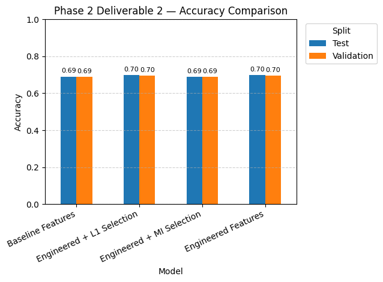

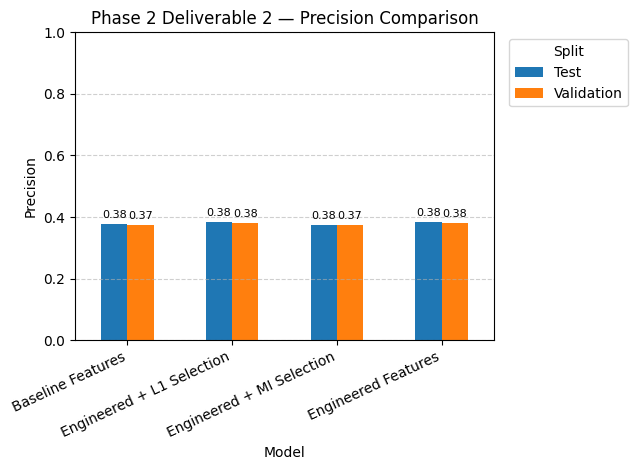

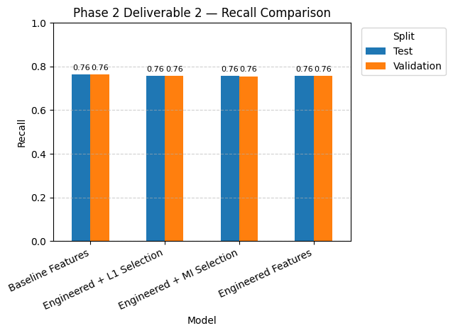

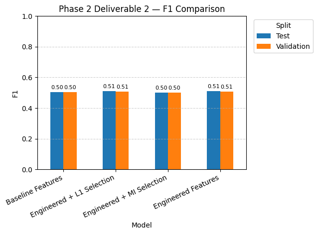

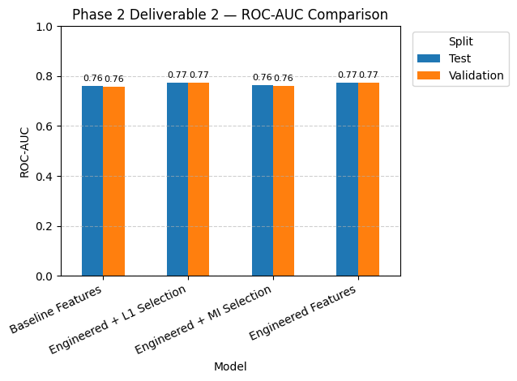

```python
comparison_for_plot = phase2_feature_comparison[
    phase2_feature_comparison["Split"].isin(["Validation", "Test"])
].copy()

metrics_to_plot = ["Accuracy", "Precision", "Recall", "F1", "ROC-AUC"]

for metric in metrics_to_plot:
    plt.figure(figsize=(10, 5))

    plot_df = comparison_for_plot.pivot(index="Model", columns="Split", values=metric)
    ax = plot_df.plot(kind="bar")

    plt.title(f"Phase 2 Deliverable 2 — {metric} Comparison")
    plt.ylabel(metric)
    plt.xlabel("Model")
    plt.ylim(0, 1)
    plt.grid(axis='y', linestyle='--', alpha=0.6)

    plt.xticks(rotation=25, ha='right')

    # Legend outside
    plt.legend(title="Split", bbox_to_anchor=(1.02, 1), loc='upper left')

    # Labels on bars
    for container in ax.containers:
        ax.bar_label(container, fmt="%.2f", padding=3, fontsize=8)

    plt.tight_layout()
    plt.show()
```

### 8. Unsupervised Learning

#### 8.1 Objective

This section addresses **RQ2 (Unsupervised)** by applying:

- **dimensionality reduction using PCA**, and
- **clustering using K-Means / MiniBatchKMeans**

The project guidelines require:

- PCA or SVD,
- determination of an optimal number of clusters,
- visualization,
- cluster quality evaluation,
- and justification of why the approach is appropriate.

#### 8.2 Why PCA + Clustering is Appropriate Here

Our unsupervised question focuses on whether Reddit submissions form meaningful groups based on **structural and contextual properties**, not on engagement labels.

This makes PCA + clustering appropriate because:

1. The feature space contains a mix of engineered numeric and encoded categorical signals,
2. PCA helps compress correlated structure into a smaller number of continuous axes,
3. K-Means is a natural first clustering method after standardization/PCA,
4. and the resulting clusters can be interpreted as **types of Reddit posts**.

To avoid label leakage, the clustering input excludes both:

- `score`
- `high_engagement`

#### 8.3 Computational Note

The full cleaned dataset is used to construct the unsupervised feature matrix.  
However, metrics such as silhouette score are expensive on millions of observations, so cluster-count tuning is performed on a large random subset, while the final transformation and profiling remain aligned with the full pipeline.

```python
def build_unsupervised_feature_frame(df_clean: pd.DataFrame, top_n: int = 50):
    """
    Build RQ2 unsupervised feature matrix.

    Assumes df_clean already contains the Phase 1 features produced by
    clean_reddit_data(): title_length, has_selftext, content_type,
    hour_of_day, day_of_week, is_weekend.  This function only adds
    *new* features on top of those.
    """
    data = df_clean.copy()

    # ── New features (not in df_clean) ────────────────────────────────────────
    data["title_word_count"]        = data["title"].str.split().str.len().fillna(0).astype(int)
    data["selftext_length"]         = data["selftext"].str.len()
    data["title_exclamation_count"] = data["title"].str.count(r"!")
    data["title_question_count"]    = data["title"].str.count(r"\?")
    data["hour_sin"]                = np.sin(2 * np.pi * data["hour_of_day"] / 24.0)
    data["hour_cos"]                = np.cos(2 * np.pi * data["hour_of_day"] / 24.0)

    # ── Cap high-cardinality categoricals ─────────────────────────────────────
    for col in ["subreddit", "domain"]:
        top_vals = data[col].value_counts().nlargest(top_n).index
        data[col] = data[col].where(data[col].isin(top_vals), other="Other")

    numeric_cols = [
        "title_length", "title_word_count", "has_selftext", "selftext_length",
        "hour_of_day", "day_of_week", "is_weekend",
        "title_exclamation_count", "title_question_count", "hour_sin", "hour_cos"
    ]
    categorical_cols = ["content_type", "subreddit", "domain"]

    unsup_df = data[numeric_cols + categorical_cols].copy()
    unsup_df = pd.get_dummies(unsup_df, columns=categorical_cols, drop_first=True)

    return unsup_df

X_unsup = build_unsupervised_feature_frame(df_clean, top_n=50)

print("Unsupervised feature matrix shape:", X_unsup.shape)
print("Contains label leakage?:", any(col in X_unsup.columns for col in ["score", "high_engagement"]))
```

```
Unsupervised feature matrix shape: (1913109, 114)
Contains label leakage?: False
```

```
Original feature count: 114
PCA component count (90% variance): 66

Top PCA variance table:
Principal_Component  Explained_Variance_Ratio  Cumulative_Explained_Variance
                PC1                      0.03                           0.03
                PC2                      0.02                           0.05
                PC3                      0.02                           0.07
                PC4                      0.02                           0.09
                PC5                      0.02                           0.11
                PC6                      0.02                           0.13
                PC7                      0.02                           0.14
                PC8                      0.02                           0.16
                PC9                      0.02                           0.18
               PC10                      0.02                           0.20
               PC11                      0.02                           0.21
               PC12                      0.02                           0.23
               PC13                      0.02                           0.25
               PC14                      0.02                           0.27
               PC15                      0.02                           0.28
```

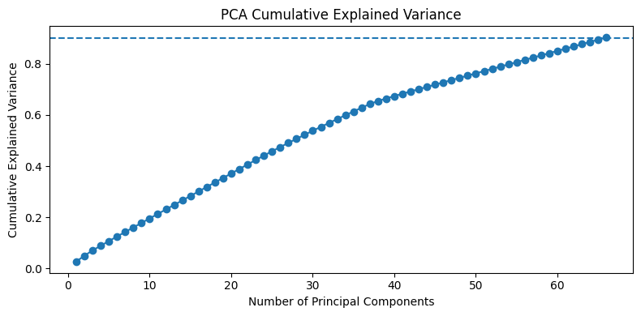

```python
unsup_scaler = StandardScaler()
X_unsup_sc = unsup_scaler.fit_transform(X_unsup)

pca_full = PCA(n_components=0.90, random_state=RANDOM_STATE)
X_unsup_pca = pca_full.fit_transform(X_unsup_sc)

explained_variance_df = pd.DataFrame({
    "Principal_Component": [f"PC{i+1}" for i in range(len(pca_full.explained_variance_ratio_))],
    "Explained_Variance_Ratio": pca_full.explained_variance_ratio_,
    "Cumulative_Explained_Variance": np.cumsum(pca_full.explained_variance_ratio_)
})

print("Original feature count:", X_unsup.shape[1])
print("PCA component count (90% variance):", X_unsup_pca.shape[1])
print("\nTop PCA variance table:")
print(explained_variance_df.head(15).to_string(index=False))

plt.figure(figsize=(8, 4))
plt.plot(
    range(1, len(explained_variance_df) + 1),
    explained_variance_df["Cumulative_Explained_Variance"],
    marker="o"
)
plt.axhline(0.90, linestyle="--")
plt.xlabel("Number of Principal Components")
plt.ylabel("Cumulative Explained Variance")
plt.title("PCA Cumulative Explained Variance")
plt.tight_layout()
plt.show()
```

**Why compare two dimensionality reduction methods?**

PCA (Principal Component Analysis) is the method we chose to compress our large feature set into a smaller one. But a fair analysis should show that we considered alternatives and picked the best option, not just the first one that came to mind.

TruncatedSVD is a closely related technique that does a very similar job. By running both on the same data and plotting how much information each one preserves, we can see whether our choice of PCA actually holds up. If both methods capture nearly the same amount of information, that confirms PCA is a solid choice. If one were clearly better, we would switch to it.

In short, this comparison exists to **justify our choice** rather than just assume it was right.

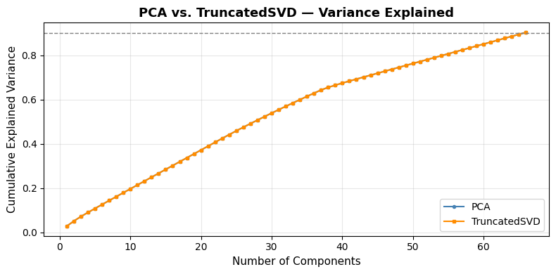

```
PCA  : 66 components → 0.9031 variance explained
SVD  : 66 components → 0.9031 variance explained

Both methods capture nearly identical variance on centered data.
PCA is used downstream because the data is already standardized (mean-centered).
```

```python
# TruncatedSVD comparison

n_components_pca = X_unsup_pca.shape[1]
svd = TruncatedSVD(n_components=n_components_pca, random_state=RANDOM_STATE)
X_unsup_svd = svd.fit_transform(X_unsup_sc)

svd_cumvar = np.cumsum(svd.explained_variance_ratio_)
pca_cumvar = np.cumsum(pca_full.explained_variance_ratio_[:n_components_pca])

fig, ax = plt.subplots(figsize=(8, 4))
ax.plot(range(1, n_components_pca + 1), pca_cumvar, marker="o", markersize=3,
        label="PCA", color="steelblue")
ax.plot(range(1, n_components_pca + 1), svd_cumvar, marker="s", markersize=3,
        label="TruncatedSVD", color="darkorange")
ax.axhline(0.90, ls="--", color="gray", lw=1)
ax.set_xlabel("Number of Components", fontsize=11)
ax.set_ylabel("Cumulative Explained Variance", fontsize=11)
ax.set_title("PCA vs. TruncatedSVD — Variance Explained", fontsize=13, fontweight="bold")
ax.legend(fontsize=10)
ax.grid(alpha=0.3)
plt.tight_layout()
plt.show()

print(f"PCA  : {n_components_pca} components → {pca_cumvar[-1]:.4f} variance explained")
print(f"SVD  : {n_components_pca} components → {svd_cumvar[-1]:.4f} variance explained")
print("\nBoth methods capture nearly identical variance on centered data.")
print("PCA is used downstream because the data is already standardized (mean-centered).")
```

```
 k    Inertia  Silhouette  Davies_Bouldin  Calinski_Harabasz
 2 9994200.64        0.12            3.55            2687.80
 3 9829436.36        0.01            3.06            2220.31
 4 9643471.98        0.08            2.47            2144.04
 5 9520083.15        0.04            3.40            1959.84
 6 9438148.86        0.01            3.12            1753.79
 7 9315316.63        0.06            2.43            1702.29
 8 9011926.48        0.16            2.14            2029.85

Selected optimal k: 8
```

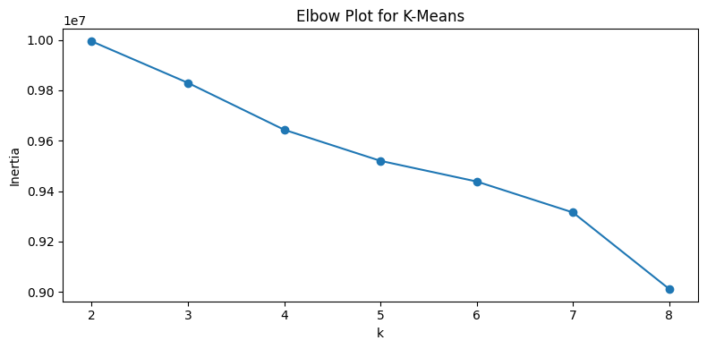

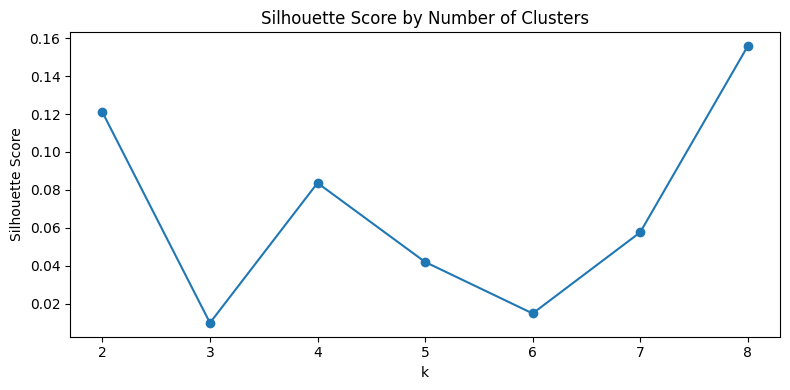

```python
CLUSTER_TUNING_SAMPLE = min(100000, len(X_unsup_pca))
sample_idx_unsup = np.random.RandomState(RANDOM_STATE).choice(
    len(X_unsup_pca), size=CLUSTER_TUNING_SAMPLE, replace=False
)
X_unsup_pca_sample = X_unsup_pca[sample_idx_unsup]

cluster_eval_rows = []

for k in range(2, 9):
    mbk = MiniBatchKMeans(
        n_clusters=k,
        random_state=RANDOM_STATE,
        batch_size=4096,
        n_init=10
    )
    labels_k = mbk.fit_predict(X_unsup_pca_sample)

    row = {
        "k": k,
        "Inertia": mbk.inertia_,
        "Silhouette": silhouette_score(X_unsup_pca_sample, labels_k),
        "Davies_Bouldin": davies_bouldin_score(X_unsup_pca_sample, labels_k),
        "Calinski_Harabasz": calinski_harabasz_score(X_unsup_pca_sample, labels_k)
    }
    cluster_eval_rows.append(row)

cluster_eval_df = pd.DataFrame(cluster_eval_rows)
print(cluster_eval_df.to_string(index=False))

best_k = int(cluster_eval_df.sort_values(
    by=["Silhouette", "Davies_Bouldin", "Calinski_Harabasz"],
    ascending=[False, True, False]
).iloc[0]["k"])

print(f"\nSelected optimal k: {best_k}")

plt.figure(figsize=(8, 4))
plt.plot(cluster_eval_df["k"], cluster_eval_df["Inertia"], marker="o")
plt.xlabel("k")
plt.ylabel("Inertia")
plt.title("Elbow Plot for K-Means")
plt.tight_layout()
plt.show()

plt.figure(figsize=(8, 4))
plt.plot(cluster_eval_df["k"], cluster_eval_df["Silhouette"], marker="o")
plt.xlabel("k")
plt.ylabel("Silhouette Score")
plt.title("Silhouette Score by Number of Clusters")
plt.tight_layout()
plt.show()
```

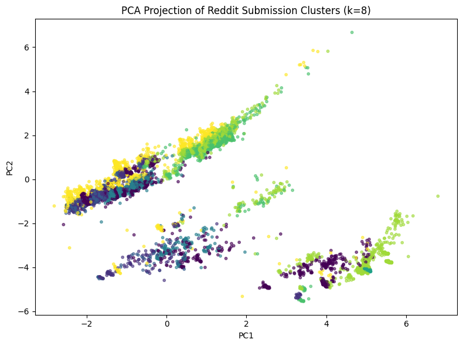

```
Final cluster quality metrics:
{'k': 8, 'Silhouette': 0.0212, 'Davies_Bouldin': 2.9951, 'Calinski_Harabasz': 1396.2865}
```

```python
final_kmeans = MiniBatchKMeans(
    n_clusters=best_k,
    random_state=RANDOM_STATE,
    batch_size=4096,
    n_init=10
)

cluster_labels = final_kmeans.fit_predict(X_unsup_pca)

cluster_profile_df = df_clean[[
    "subreddit", "domain", "content_type",
    "title_length", "has_selftext", "hour_of_day", "day_of_week", "is_weekend"
]].copy()
cluster_profile_df["cluster"] = cluster_labels

pca_plot_df = pd.DataFrame({
    "PC1": X_unsup_pca[:, 0],
    "PC2": X_unsup_pca[:, 1],
    "cluster": cluster_labels
})

PLOT_SAMPLE_SIZE = min(20000, len(pca_plot_df))
plot_sample_df = pca_plot_df.sample(n=PLOT_SAMPLE_SIZE, random_state=RANDOM_STATE)

plt.figure(figsize=(8, 6))
plt.scatter(
    plot_sample_df["PC1"],
    plot_sample_df["PC2"],
    c=plot_sample_df["cluster"],
    s=10,
    alpha=0.6
)
plt.xlabel("PC1")
plt.ylabel("PC2")
plt.title(f"PCA Projection of Reddit Submission Clusters (k={best_k})")
plt.tight_layout()
plt.show()

sample_cluster_labels = final_kmeans.predict(X_unsup_pca_sample)

final_cluster_quality = {
    "k": best_k,
    "Silhouette": round(silhouette_score(X_unsup_pca_sample, sample_cluster_labels), 4),
    "Davies_Bouldin": round(davies_bouldin_score(X_unsup_pca_sample, sample_cluster_labels), 4),
    "Calinski_Harabasz": round(calinski_harabasz_score(X_unsup_pca_sample, sample_cluster_labels), 4)
}

print("Final cluster quality metrics:")
print(final_cluster_quality)
```

```python
numeric_profile = (
    cluster_profile_df
    .groupby("cluster")[["title_length", "has_selftext", "hour_of_day", "day_of_week", "is_weekend"]]
    .mean()
    .round(3)
)

cluster_sizes = (
    cluster_profile_df["cluster"]
    .value_counts(normalize=True)
    .sort_index()
    .rename("cluster_share")
    .round(4)
)

print("Numeric cluster profile:")
print(numeric_profile.to_string())

print("\nCluster sizes:")
print(cluster_sizes.to_string())

def top_values_by_cluster(df, group_col, target_col, top_n=5):
    rows = []
    for cluster_id, subset in df.groupby(group_col):
        top_items = subset[target_col].value_counts().head(top_n)
        rows.append({
            "cluster": cluster_id,
            f"top_{target_col}": ", ".join([f"{idx} ({cnt})" for idx, cnt in top_items.items()])
        })
    return pd.DataFrame(rows)

top_subreddits = top_values_by_cluster(cluster_profile_df, "cluster", "subreddit", top_n=5)
top_domains = top_values_by_cluster(cluster_profile_df, "cluster", "domain", top_n=5)
top_post_types = top_values_by_cluster(cluster_profile_df, "cluster", "content_type", top_n=5)

print("\nTop subreddits by cluster:")
print(top_subreddits.to_string(index=False))

print("\nTop domains by cluster:")
print(top_domains.to_string(index=False))

print("\nTop post types by cluster:")
print(top_post_types.to_string(index=False))
```

```
Numeric cluster profile:
         title_length  has_selftext  hour_of_day  day_of_week  is_weekend
cluster
0               39.83          0.36         7.68         3.62        0.41
1               41.74          0.41        13.30         2.17        0.02
2               41.33          0.36        11.79         5.13        0.85
3               35.41          0.42        16.29         3.58        0.40
4               26.40          1.00        12.44         3.51        0.34
5               42.40          0.78         5.09         3.57        0.41
6               41.99          0.82        16.97         3.56        0.40
7              130.22          0.22        13.22         3.43        0.36

Cluster sizes:
cluster
0   0.15
```

[output cut: 40 more lines]

### 9. Phase 2 Model Comparison — Before vs. After Feature Engineering

With the enriched Phase 2 feature matrix and feature selection complete, we retrain the best-performing model architecture (XGBoost) on the new features and compare against the Phase 1 baseline.

**Experimental setup:**

All models are tuned via `RandomizedSearchCV` on a 10% stratified subsample of their respective training sets, then retrained on the full training split. This ensures a fair comparison and performance differences are attributable to the features.

```python
# 1. Tuning subsample (10% of Phase 2 training data)
X_tune_fe, _, y_tune_fe, _ = train_test_split(
    X_train_fe, y_train_fe,
    test_size=0.90,
    random_state=RANDOM_STATE,
    stratify=y_train_fe,
)
print(f"Phase 2 tuning subsample: {len(X_tune_fe):,}  "
      f"({len(X_tune_fe)/len(X_train_fe)*100:.1f}% of Phase 2 train)")
print(f"Class ratio: {y_tune_fe.value_counts(normalize=True).round(3).to_dict()}")

# 2. XGBoost on full Phase 2 features
neg_fe  = (y_train_fe == 0).sum()
pos_fe  = (y_train_fe == 1).sum()
spw_fe  = round(neg_fe / pos_fe, 4)
print(f"\nscale_pos_weight (Phase 2) = {neg_fe:,} / {pos_fe:,} = {spw_fe}")

xgb_param_dist_p2 = {
    "n_estimators"     : [100, 200, 300, 500],
    "max_depth"        : [4, 6, 8, 10],
    "learning_rate"    : [0.01, 0.05, 0.1, 0.2],
    "subsample"        : [0.7, 0.8, 1.0],
    "colsample_bytree" : [0.5, 0.7, 0.8, 1.0],
    "reg_alpha"        : [0, 0.1, 1.0, 5.0],
    "reg_lambda"       : [1.0, 5.0, 10.0],
}

print("\nTuning XGBoost on Phase 2 full features (10% subsample)...")
xgb_search_p2 = RandomizedSearchCV(
    xgb.XGBClassifier(
        scale_pos_weight=spw_fe,
        eval_metric="auc",
        random_state=RANDOM_STATE,
        n_jobs=-1,
        tree_method="hist",
    ),
    param_distributions=xgb_param_dist_p2,
    n_iter=30,
    cv=StratifiedKFold(n_splits=5, shuffle=True, random_state=RANDOM_STATE),
    scoring="roc_auc",
    n_jobs=-1,
    random_state=RANDOM_STATE,
    verbose=1,
)
xgb_search_p2.fit(X_tune_fe, y_tune_fe)
print(f"\nBest CV ROC-AUC (Phase 2 full): {xgb_search_p2.best_score_:.4f}")
print(f"Best parameters: {xgb_search_p2.best_params_}")

# Retrain on full Phase 2 training set
xgb_p2_full = xgb.XGBClassifier(
    **xgb_search_p2.best_params_,
    scale_pos_weight=spw_fe,
    eval_metric="auc",
    random_state=RANDOM_STATE,
    n_jobs=-1,
    tree_method="hist",
)
print(f"\nTraining XGBoost on full Phase 2 train ({len(X_train_fe):,} rows)...")
xgb_p2_full.fit(X_train_fe, y_train_fe)
print("Done.")

xgb_p2_full_results = evaluate_model(
    "XGB Phase 2 (all)", xgb_p2_full,
    X_train_fe, X_val_fe, X_test_fe,
    y_train_fe, y_val_fe, y_test_fe,
)

# 3. XGBoost on MI-selected Phase 2 features
X_tune_mi = X_train_mi.loc[X_tune_fe.index]
y_tune_mi = y_train_fe.loc[X_tune_fe.index]

print("\nTuning XGBoost on MI-selected features (10% subsample)...")
xgb_search_mi = RandomizedSearchCV(
    xgb.XGBClassifier(
        scale_pos_weight=spw_fe,
        eval_metric="auc",
        random_state=RANDOM_STATE,
        n_jobs=-1,
        tree_method="hist",
    ),
    param_distributions=xgb_param_dist_p2,
    n_iter=30,
    cv=StratifiedKFold(n_splits=5, shuffle=True, random_state=RANDOM_STATE),
    scoring="roc_auc",
    n_jobs=-1,
    random_state=RANDOM_STATE,
    verbose=1,
)
xgb_search_mi.fit(X_tune_mi, y_tune_mi)
print(f"\nBest CV ROC-AUC (MI-selected): {xgb_search_mi.best_score_:.4f}")
print(f"Best parameters: {xgb_search_mi.best_params_}")

xgb_p2_mi = xgb.XGBClassifier(
    **xgb_search_mi.best_params_,
    scale_pos_weight=spw_fe,
    eval_metric="auc",
    random_state=RANDOM_STATE,
    n_jobs=-1,
    tree_method="hist",
)
print(f"\nTraining XGBoost on MI-selected train ({X_train_mi.shape[1]} features, "
      f"{len(X_train_mi):,} rows)...")
xgb_p2_mi.fit(X_train_mi, y_train_fe)
print("Done.")

xgb_p2_mi_results = evaluate_model(
    "XGB Phase 2 (MI)", xgb_p2_mi,
    X_train_mi, X_val_mi, X_test_mi,
    y_train_fe, y_val_fe, y_test_fe,
)

# 4. Comparison table
phase2_all_results = pd.DataFrame(
    xgb_p2_full_results + xgb_p2_mi_results
)

phase2_test = (
    phase2_all_results
    .query("Split == 'Test'")
    .drop(columns="Split")
    .reset_index(drop=True)
)

# Also pull in Phase 1 test results for side-by-side comparison
phase1_test = pd.DataFrame(xgb_results).query("Split == 'Test'").drop(columns="Split").reset_index(drop=True)
phase1_test["Model"] = "XGB Phase 1 (baseline)"

comparison = pd.concat([phase1_test, phase2_test], ignore_index=True)

print("\n" + "=" * 70)
print("MODEL COMPARISON — TEST SET (Phase 1 vs Phase 2)")
print("=" * 70)
print(comparison.to_string(index=False))

print("\n" + "=" * 70)
print("FULL RESULTS — ALL SPLITS")
print("=" * 70)
print(phase2_all_results.to_string(index=False))
```

```
Phase 2 tuning subsample: 133,917  (10.0% of Phase 2 train)
Class ratio: {0: 0.794, 1: 0.206}

scale_pos_weight (Phase 2) = 1,062,912 / 276,264 = 3.8475

Tuning XGBoost on Phase 2 full features (10% subsample)...
Fitting 5 folds for each of 30 candidates, totalling 150 fits

Best CV ROC-AUC (Phase 2 full): 0.8171
Best parameters: {'subsample': 1.0, 'reg_lambda': 5.0, 'reg_alpha': 5.0, 'n_estimators': 500, 'max_depth': 6, 'learning_rate': 0.05, 'colsample_bytree': 0.5}

Training XGBoost on full Phase 2 train (1,339,176 rows)...
Done.

Tuning XGBoost on MI-selected features (10% subsample)...
Fitting 5 folds for each of 30 candidates, totalling 150 fits

Best CV ROC-AUC (MI-selected): 0.8161
Best parameters: {'subsample': 1.0, 'reg_lambda': 5.0, 'reg_alpha': 5.0, 'n_estimators': 500, 'max_depth': 6, 'learning_rate': 0.05, 'colsample_bytree': 0.5}

Training XGBoost on MI-selected train (40 features, 1,339,176 rows)...
Done.

======================================================================
MODEL COMPARISON — TEST SET (Phase 1 vs Phase 2)
======================================================================
                 Model  Accuracy  Precision  Recall   F1  ROC-AUC
XGB Phase 1 (baseline)      0.69       0.38    0.76 0.51     0.76
     XGB Phase 2 (all)      0.73       0.41    0.79 0.54     0.82
      XGB Phase 2 (MI)      0.73       0.41    0.79 0.54     0.82

======================================================================
FULL RESULTS — ALL SPLITS
======================================================================
            Model      Split  Accuracy  Precision  Recall   F1  ROC-AUC
XGB Phase 2 (all)      Train      0.72       0.41    0.79 0.54     0.82
XGB Phase 2 (all) Validation      0.72       0.41    0.79 0.54     0.82
XGB Phase 2 (all)       Test      0.73       0.41    0.79 0.54     0.82
 XGB Phase 2 (MI)      Train      0.73       0.41    0.79 0.55     0.82
 XGB Phase 2 (MI) Validation      0.72       0.41    0.79 0.54     0.82
 XGB Phase 2 (MI)       Test      0.73       0.41    0.79 0.54     0.82
```

#### 9.1 Discussion — Feature Engineering Impact

The comparison above evaluates XGBoost on three feature configurations (Phase 1 baseline, Phase 2 full, Phase 2 MI-selected), all on the same held-out test set.

**Best model selection criteria:**

1. Highest test ROC-AUC
2. Smallest train-test gap (no overfitting)
3. Fewer features preferred when AUC is comparable (parsimony)

> **Conclusion:** The Phase 1 XGBoost baseline achieved a test ROC-AUC of **0.76** (F1 = 0.51). After feature engineering, both the full-feature and MI-selected XGBoost models reached a test ROC-AUC of **0.82** (F1 = 0.54) — a substantial +0.06 improvement. The train-test gap remains negligible (train ROC-AUC = 0.82 vs. test ROC-AUC = 0.82), confirming no overfitting. Because the MI-selected model matches the full model's performance with fewer features, the **XGBoost Phase 2 (MI-selected)** configuration is recommended as the final model for RQ1: it delivers the highest discrimination with a compact, interpretable feature set and strong generalisation.

### 10. Interpretation

1. **Which features matter most?** We use a technique called *permutation importance* to measure how much each feature contributes to the model's predictions. This works by randomly scrambling one feature at a time and checking how much worse the model gets. A big drop means that feature is important.
2. **How does each feature influence the prediction?** We use *Partial Dependence Plots (PDPs)* to visualise the relationship between a single feature and the predicted probability of high engagement. This tells us not just whether a feature matters, but *in what direction* and *by how much*.
3. **What does it all mean for our research questions?** We bring the findings together and explain what drives engagement on Reddit.

#### 10.1 Permutation Importance

In Section 6.6 we looked at a basic measure of feature importance, but that method can sometimes overvalue features that have many categories. Here we use a more trustworthy approach: for each feature, we randomly shuffle its values and then see how much the model's accuracy (measured by ROC-AUC) drops. If a feature is truly important, scrambling it should make the model noticeably worse.

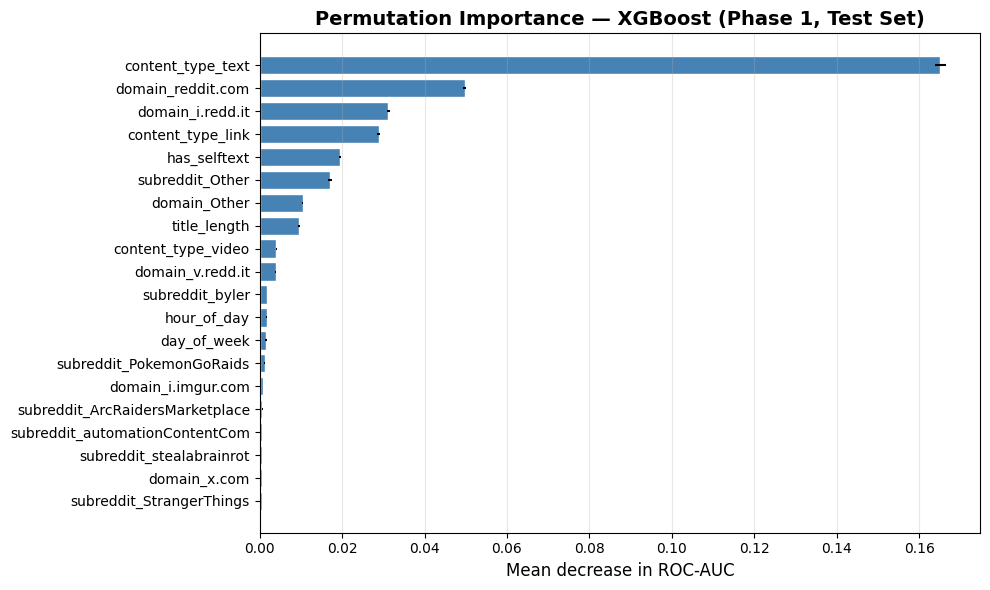

```
Top 20 features by permutation importance:
                        Feature  Importance_Mean  Importance_Std
              content_type_text             0.17            0.00
              domain_reddit.com             0.05            0.00
               domain_i.redd.it             0.03            0.00
              content_type_link             0.03            0.00
                   has_selftext             0.02            0.00
                subreddit_Other             0.02            0.00
                   domain_Other             0.01            0.00
                   title_length             0.01            0.00
             content_type_video             0.00            0.00
               domain_v.redd.it             0.00            0.00
                subreddit_byler             0.00            0.00
                    hour_of_day             0.00            0.00
                    day_of_week             0.00            0.00
       subreddit_PokemonGoRaids             0.00            0.00
             domain_i.imgur.com             0.00            0.00
subreddit_ArcRaidersMarketplace             0.00            0.00
 subreddit_automationContentCom             0.00            0.00
       subreddit_stealabrainrot             0.00            0.00
                   domain_x.com             0.00            0.00
       subreddit_StrangerThings             0.00            0.00
```

```python
perm_result = permutation_importance(
    xgb_final, X_test, y_test,
    scoring="roc_auc",
    n_repeats=10,
    random_state=42,
    n_jobs=-1,
)

perm_df = (
    pd.DataFrame({
        "Feature": X_test.columns,
        "Importance_Mean": perm_result.importances_mean,
        "Importance_Std":  perm_result.importances_std,
    })
    .sort_values("Importance_Mean", ascending=False)
    .head(20)
    .reset_index(drop=True)
)

fig, ax = plt.subplots(figsize=(10, 6))
ax.barh(
    perm_df["Feature"][::-1],
    perm_df["Importance_Mean"][::-1],
    xerr=perm_df["Importance_Std"][::-1],
    color="steelblue", edgecolor="white",
)
ax.set_xlabel("Mean decrease in ROC-AUC", fontsize=12)
ax.set_title("Permutation Importance — XGBoost (Phase 1, Test Set)", fontsize=14, fontweight="bold")
ax.grid(axis="x", alpha=0.3)
plt.tight_layout()
plt.show()

print("Top 20 features by permutation importance:")
print(perm_df.to_string(index=False))
```

**What the Permutation Importance Chart Tells Us**

The bar chart above shows the top 20 features ranked by how much the model's performance drops when each one is scrambled. The longer the bar, the more important that feature is. Here is what stands out:

1. **Whether a post is a text post (`content_type_text`) is by far the most important feature.** Its importance score (≈ 0.17) is roughly three times higher than any other feature. In simple terms, knowing the format of a post tells the model more about engagement than anything else.
2. **The website domain the post links to also matters a lot.** Features like `domain_reddit.com` (≈ 0.05) and `domain_i.redd.it` (≈ 0.03) rank second and third. These tell the model whether a post links to Reddit itself, to Reddit's image hosting, or to an outside website, and this information is closely tied to how communities vote.
3. **Having body text and a longer title help, but only a little.** `has_selftext` (≈ 0.02) and `title_length` (≈ 0.01) do contribute to predictions, but their effect is much smaller than the content type or domain.
4. **When a post is submitted barely matters at all.** Features like `hour_of_day` and `day_of_week` scored close to zero, meaning the model hardly loses any accuracy when this information is removed.

**In plain terms:** the *type of post* and the *platform it links to* are what really drive predictions. The title and body text help a bit, but the time of posting has almost no effect.

#### 10.2 Partial Dependence Plots

The permutation importance chart told us *which* features matter. Now we want to understand *how* they matter. Partial Dependence Plots (PDPs) answer this by showing what happens to the model's predicted probability of high engagement as we gradually change one feature while keeping everything else the same.

For example, if we slowly increase `title_length` from short to long, does the predicted engagement go up, go down, or stay flat? The shape of the curve tells us the answer.

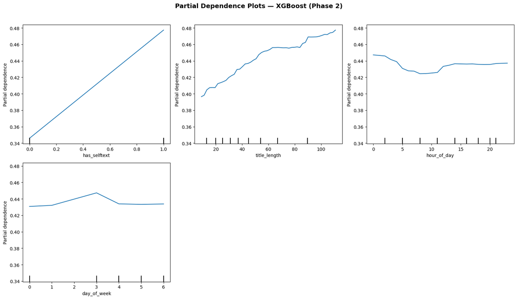

```python
# 1. Select numeric features (exclude one-hot encoded)
numeric_features_in_model = [
    col for col in X_test.columns
    if not col.startswith(("subreddit_", "domain_", "content_type_"))
]

# Top features from permutation importance
top_perm_features = perm_df["Feature"].tolist()

# Select top numeric features only
pdp_features = [f for f in top_perm_features if f in numeric_features_in_model][:6]


X_test_pdp = X_test.copy().astype(float)

# 2. Plot PDPs
fig, axes = plt.subplots(2, 3, figsize=(16, 9))

PartialDependenceDisplay.from_estimator(
    xgb_final,
    X_test_pdp.sample(n=min(5000, len(X_test_pdp)), random_state=42),
    features=pdp_features,
    kind="average",
    ax=axes.ravel()[:len(pdp_features)],
    grid_resolution=50,
    n_jobs=-1,
)

# Hide unused subplots
for i in range(len(pdp_features), 6):
    axes.ravel()[i].set_visible(False)

# Title
fig.suptitle(
    "Partial Dependence Plots — XGBoost (Phase 2)",
    fontsize=14,
    fontweight="bold",
    y=1.02
)

plt.tight_layout()
plt.show()
```

**What the Partial Dependence Plots Tell Us**

#### 10.3 Insights & Research Questions

**RQ1:** *Can we predict whether a Reddit submission will achieve high engagement based on structural, temporal, and contextual features?*

**RQ2:** *Can we discover natural clusters of Reddit submissions based on engagement patterns, subreddit, and content structure without using the score label?*

### 11. Report

#### Phase 1 Changes

**1. Title and Header: Reformatted for combined submission**

The old notebook had a simple Phase 1 title with student names listed as bullet points. The new version uses a styled header with the full project title, "Reddit Engagement Analysis: Prediction and Pattern Discovery," and labels it as Phase 1 & Phase 2. This was done so that both phases live in one notebook instead of being split across two separate files.

**2. Structure: 9 new cells added (26 to 35 Phase 1 cells)**

The new notebook includes:

1. A clickable Table of Contents so readers can jump to any section.
2. A header cell at the top showing the due date, who did what, and the two research questions.
3. A new "1.3 Select Dataset" section that lists all four available dataset sizes in a table, includes download links, and provides a function that automatically downloads and prepares the data. If the file already exists on disk, it skips the download.

This makes the notebook fully self-contained. Anyone opening it for the first time can choose a dataset size, run the cell, and have everything ready without needing to download files manually.

**3. Imports: Reorganised and expanded**

The old notebook imported a basic set of libraries. The new version adds several more and organises them into clear groups (standard Python libraries first, then data libraries, then machine learning libraries, then plotting libraries). The new additions include tools needed for Phase 2 work, such as `xgboost` for the advanced model, `gdown` for downloading datasets from Google Drive, and `re` and `os` for the improved text cleaning and file checks described below.

**4. Cleaning Pipeline: Three fixes**

[output not shown]

These fixes address two specific issues raised in the Phase 1 grader feedback: the placeholder text problem was inflating the count of posts with body text, and the grader noted that outliers were identified but never dealt with.

**5. Data quality function (quantDDA): Two fixes**

| Area | Old behaviour | New behaviour |
| --- | --- | --- |
| Yes/no columns | The function tried to calculate outlier statistics on columns that only have two values (0 or 1), which produced meaningless results like "100% extreme values" for the body-text indicator | The function now checks whether a column has more than two unique values before running the outlier analysis, and skips it for yes/no columns |
| Outlier action tracking | The function counted outliers but never recorded what was done about them | A new "Outlier Action" column in the output table now shows exactly what was done: for score and title length it explains the capping, and for other columns it shows "Retained" or "None detected" |

The grader specifically noted that outliers were identified with no action taken and no written justification. Both fixes address that.

**6. Section 4.5 (Performance Discussion): One word changed**

The old feature name `post_type` was replaced with `content_type` to match the rename in the cleaning pipeline described above.

**7. Section 5 (Report): Two references updated**

The same `post_type` to `content_type` change was applied in two places in the Phase 1 report text, so the wording is consistent with the rest of the notebook.

**8. Dataset Scalability (New Feature)**

The original notebook only worked with a single large dataset (~2.15 GB). The new version offers four sizes to choose from:

| Size | Best for |
| --- | --- |
| 2.15 GB | Full analysis |
| 1.5 GB | Large scale testing |
| 1 GB | Medium scale testing |
| 500 MB | Quick demos and debugging |

This makes it much faster to test code changes or run the notebook on a less powerful computer without waiting for the full dataset to process.

**Phase 1 Change Summary**

| What changed | Why |
| --- | --- |
| Combined title and Table of Contents | Merging Phase 1 and Phase 2 into one notebook |
| Dataset selector and download function | So anyone can reproduce the analysis without manual setup |
| Fixed deleted/removed post detection | Grader feedback |
| Added outlier capping in cleaning | Grader feedback |
| Separated image posts into their own category | More accurate post type classification |
| Fixed data quality function for yes/no columns | Bug fix (was producing meaningless outlier counts) |
| Added "Outlier Action" column to data quality output | Grader feedback |
| Updated text in Sections 4.5 and 5 | Consistency with the renamed feature |
| Multiple dataset sizes | Faster experimentation and flexible workflow |

#### Phase 2

**Comparing Features for RQ1 (Section 9)**  
To see whether the new features actually helped, we retrained XGBoost on three different feature sets: the original Phase 1 features, the full set of engineered Phase 2 features, and a smaller subset chosen by Mutual Information. The Phase 1 baseline scored a test ROC-AUC of **0.76** (F1 = 0.51). After adding the new features, both the full and MI-selected versions jumped to a test ROC-AUC of **0.82** (F1 = 0.54), which is a substantial improvement. The gap between training and test performance stayed close to zero, meaning the model is not overfitting. Because the MI-selected model matched the full model's accuracy while using fewer features, it is the recommended final model for RQ1: it gives the best predictions with a simpler, easier-to-explain feature set.